# ferm_final

Installing and Importing Libraries

```python
# !pip3 install pandas_datareader
```

```python
#!pip3 install yfinance
```

```python
# !pip3 install pandas-datareader
```

```python
import numpy as np
import pandas_datareader as pdr
import datetime as dt
import pandas as pd
import matplotlib.pyplot as plt
%matplotlib inline
# %matplotlib notebook
import scipy.optimize as sco
import seaborn as sns
```

Importing Data

```python
# Readymade Portfolio 1
# tickers = ['ITC.NS', 'AMBUJACEM.NS', 'ADANIPORTS.NS', 'SBIN.NS','LT.NS','PATANJALI.NS','IRB.NS','FORTIS.NS','LINDEINDIA.NS','ESCORTS.NS','ZEEL.NS','CRISIL.NS','KOTAKBANK.NS','AEGISCHEM.NS','HFCL.NS','SUNPHARMA.NS','TATACOMM.NS','RELIANCE.NS','IPL.NS','CUMMINSIND.NS']
# Readymade Portfolio 2
# tickers = ['KOTAKBANK.NS', 'TATAMOTORS.NS', 'GRASIM.NS', 'COALINDIA.NS', 'SHREECEM.NS', 'EICHERMOT.NS', 'AXISBANK.NS', 'SBIN.NS','IOC.NS','BPCL.NS','UPL.NS', 'MARUTI.NS', 'SUNPHARMA.NS', 'ONGC.NS', 'BRITANNIA.NS', 'ADANIPORTS.NS', 'NESTLEIND.NS', 'TATASTEEL.NS', 'DRREDDY.NS']
# Pharmaceutical Portfolio
# tickers = ['SUNPHARMA.BO', 'DRREDDY.BO', 'DIVISLAB.BO', 'CIPLA.BO', 'BIOCON.BO', 'TORNTPHARM.BO', 'AUROPHARMA.BO', 'LUPIN.BO','ABBOTINDIA.BO','ALKEM.BO','APOLLOHOSP.BO', 'IPCALAB.BO', 'GLAXO.BO', 'PFIZER.BO', 'SYNGENE.BO', 'APLLTD.BO', 'SANOFI.BO', 'LALPATHLAB.BO', 'LAURUSLABS.BO','NATCOPHARM.BO']
# Random Portfolio
tickers = ['DABUR.BO', 'ONGC.BO', 'BRITANNIA.BO', 'TECHM.BO','DIVISLAB.BO','M&M.BO','ICICIPRULI.BO','UNITDSPR.BO','MARICO.BO','HAVELLS.BO','DLF.BO','GRASIM.BO','AMBUJACEM.BO','PUNJABCHEM.BO','ARCHIES.BO','ZEEMEDIA.BO','ERIS.BO','HINDZINC.BO','MRF.BO','NESTLEIND.BO']
# Financial Portfolio
# tickers = ['BOMOXY-B1.BO', 'AXISBANK.BO', 'IKAB.BO', 'JPOLYINVST.BO','ICRA.BO','KOTAKBANK.BO','DHUNINV.BO','SBILIFE.BO','PILANIINVS.BO','ICICIBANK.BO','THACKER.BO','ORACLECR.BO','JINDALPHOT.BO','CGCL.BO','CANBK.BO','MONARCH.BO','SUMEDHA.BO','SYSTMTXC.BO','INDOTHAI.BO','SILINV.BO']
start = dt.datetime(2019, 10, 21)
data = pdr.get_data_yahoo(tickers, start)
```

```python
data.head()
```

| Attributes Symbols Date | Adj Close DABUR.BO | Adj Close ONGC.BO | Adj Close BRITANNIA.BO | Adj Close TECHM.BO | Adj Close DIVISLAB.BO | Adj Close M&M.BO | Adj Close ICICIPRULI.BO | Adj Close UNITDSPR.BO | Adj Close MARICO.BO | Adj Close HAVELLS.BO | ... | Volume DLF.BO | Volume GRASIM.BO | Volume AMBUJACEM.BO | Volume PUNJABCHEM.BO | Volume ARCHIES.BO | Volume ZEEMEDIA.BO | Volume ERIS.BO | Volume HINDZINC.BO | Volume MRF.BO | Volume NESTLEIND.BO |
| --- | --- | --- | --- | --- | --- | --- | --- | --- | --- | --- | --- | --- | --- | --- | --- | --- | --- | --- | --- | --- | --- |
| 2019-10-22 | 461.332672 | 121.081749 | 2981.373535 | 655.097595 | 1709.491821 | 582.371033 | 477.070099 | 612.099976 | 372.878204 | 665.369080 | ... | 1330557.0 | 58864.0 | 659243.0 | 230.0 | 9240.0 | 2340839.0 | 478.0 | 49654.0 | 112.0 | 7240.0 |
| 2019-10-23 | 460.795471 | 119.233803 | 3026.734375 | 663.540100 | 1702.035889 | 576.717957 | 482.089783 | 619.849976 | 371.510040 | 661.004333 | ... | 414809.0 | 33002.0 | 453880.0 | 273.0 | 1108.0 | 272649.0 | 169.0 | 87710.0 | 119.0 | 2339.0 |
| 2019-10-24 | 458.695648 | 118.183846 | 3018.194580 | 662.490601 | 1731.172485 | 566.337524 | 476.920990 | 609.150024 | 372.359253 | 657.080811 | ... | 607409.0 | 338792.0 | 155763.0 | 0.0 | 2835.0 | 150505.0 | 791.0 | 27063.0 | 711.0 | 2253.0 |
| 2019-10-25 | 454.495941 | 117.133873 | 2999.783936 | 657.516296 | 1724.795776 | 563.559753 | 480.847260 | 627.450012 | 371.179810 | 651.931335 | ... | 818548.0 | 121665.0 | 112629.0 | 139.0 | 927.0 | 87308.0 | 1160.0 | 48559.0 | 193.0 | 5325.0 |
| 2019-10-27 | 458.158508 | 117.553864 | 2992.163086 | 663.403320 | 1724.893799 | 576.279297 | 482.487366 | 628.849976 | 369.528656 | 654.971924 | ... | 85675.0 | 18679.0 | 11462.0 | 103.0 | 700.0 | 218391.0 | 164.0 | 36322.0 | 40.0 | 813.0 |

5 rows × 120 columns

```python
# data.keys()
```

```python
data_1=data['Close']
```

```python
data_1
```

| Symbols Date | DABUR.BO | ONGC.BO | BRITANNIA.BO | TECHM.BO | DIVISLAB.BO | M&M.BO | ICICIPRULI.BO | UNITDSPR.BO | MARICO.BO | HAVELLS.BO | DLF.BO | GRASIM.BO | AMBUJACEM.BO | PUNJABCHEM.BO | ARCHIES.BO | ZEEMEDIA.BO | ERIS.BO | HINDZINC.BO | MRF.BO | NESTLEIND.BO |
| --- | --- | --- | --- | --- | --- | --- | --- | --- | --- | --- | --- | --- | --- | --- | --- | --- | --- | --- | --- | --- |
| 2019-10-22 | 472.350006 | 144.149994 | 3246.850098 | 717.750000 | 1742.550049 | 597.500000 | 479.950012 | 612.099976 | 395.200012 | 678.349976 | 178.199997 | 756.549988 | 195.800003 | 533.099976 | 18.600000 | 5.360000 | 425.000000 | 209.949997 | 64192.101562 | 15039.099609 |
| 2019-10-23 | 471.799988 | 141.949997 | 3296.250000 | 727.000000 | 1734.949951 | 591.700012 | 485.000000 | 619.849976 | 393.750000 | 673.900024 | 174.850006 | 743.200012 | 196.800003 | 533.750000 | 18.600000 | 5.470000 | 419.149994 | 210.050003 | 64344.101562 | 14982.349609 |
| 2019-10-24 | 469.649994 | 140.699997 | 3286.949951 | 725.849976 | 1764.650024 | 581.049988 | 479.799988 | 609.150024 | 394.649994 | 669.900024 | 176.500000 | 706.549988 | 197.850006 | 533.750000 | 18.200001 | 5.300000 | 433.450012 | 211.399994 | 63550.148438 | 14677.200195 |
| 2019-10-25 | 465.350006 | 139.449997 | 3266.899902 | 720.400024 | 1758.150024 | 578.200012 | 483.750000 | 627.450012 | 393.399994 | 664.650024 | 180.949997 | 710.049988 | 197.350006 | 539.000000 | 18.500000 | 5.460000 | 430.250000 | 211.199997 | 63257.398438 | 14794.849609 |
| 2019-10-27 | 469.100006 | 139.949997 | 3258.600098 | 726.849976 | 1758.250000 | 591.250000 | 485.399994 | 628.849976 | 391.649994 | 667.750000 | 179.500000 | 703.150024 | 197.699997 | 546.150024 | 18.799999 | 5.490000 | 434.750000 | 217.000000 | 63250.550781 | 14808.299805 |
| ... | ... | ... | ... | ... | ... | ... | ... | ... | ... | ... | ... | ... | ... | ... | ... | ... | ... | ... | ... | ... |
| 2022-10-20 | 535.400024 | 129.699997 | 3789.600098 | 1041.000000 | 3651.300049 | 1250.400024 | 519.049988 | 831.049988 | 523.450012 | 1208.750000 | 373.450012 | 1689.050049 | 517.549988 | 1099.849976 | 20.650000 | 16.200001 | 707.650024 | 278.549988 | 84231.250000 | 20054.650391 |
| 2022-10-21 | 537.549988 | 131.500000 | 3791.449951 | 1041.250000 | 3569.550049 | 1256.849976 | 509.450012 | 820.400024 | 518.950012 | 1166.650024 | 370.049988 | 1675.449951 | 512.250000 | 1132.050049 | 20.250000 | 16.049999 | 731.200012 | 281.000000 | 86166.898438 | 20276.199219 |
| 2022-10-24 | 537.099976 | 132.850006 | 3802.899902 | 1048.050049 | 3612.000000 | 1270.550049 | 511.600006 | 835.400024 | 519.900024 | 1176.199951 | 367.549988 | 1697.550049 | 516.950012 | 1161.400024 | 20.400000 | 16.150000 | 737.250000 | 283.250000 | 86225.101562 | 20867.900391 |
| 2022-10-25 | 532.099976 | 130.649994 | 3711.600098 | 1082.550049 | 3599.899902 | 1280.750000 | 503.549988 | 863.750000 | 516.900024 | 1175.949951 | 369.750000 | 1715.199951 | 513.000000 | 1152.699951 | 20.200001 | 16.200001 | 712.099976 | 284.000000 | 87334.148438 | 20281.650391 |
| 2022-10-27 | 549.349976 | 131.699997 | 3753.600098 | 1075.150024 | 3621.649902 | 1293.150024 | 500.399994 | 873.650024 | 519.299988 | 1186.099976 | 383.500000 | 1724.000000 | 527.700012 | 1258.199951 | 20.150000 | 16.100000 | 727.900024 | 284.049988 | 87419.796875 | 20101.250000 |

751 rows × 20 columns

```python
data_1/data_1.iloc[0]
```

| Symbols Date | DABUR.BO | ONGC.BO | BRITANNIA.BO | TECHM.BO | DIVISLAB.BO | M&M.BO | ICICIPRULI.BO | UNITDSPR.BO | MARICO.BO | HAVELLS.BO | DLF.BO | GRASIM.BO | AMBUJACEM.BO | PUNJABCHEM.BO | ARCHIES.BO | ZEEMEDIA.BO | ERIS.BO | HINDZINC.BO | MRF.BO | NESTLEIND.BO |
| --- | --- | --- | --- | --- | --- | --- | --- | --- | --- | --- | --- | --- | --- | --- | --- | --- | --- | --- | --- | --- |
| 2019-10-22 | 1.000000 | 1.000000 | 1.000000 | 1.000000 | 1.000000 | 1.000000 | 1.000000 | 1.000000 | 1.000000 | 1.000000 | 1.000000 | 1.000000 | 1.000000 | 1.000000 | 1.000000 | 1.000000 | 1.000000 | 1.000000 | 1.000000 | 1.000000 |
| 2019-10-23 | 0.998836 | 0.984738 | 1.015215 | 1.012887 | 0.995639 | 0.990293 | 1.010522 | 1.012661 | 0.996331 | 0.993440 | 0.981201 | 0.982354 | 1.005107 | 1.001219 | 1.000000 | 1.020522 | 0.986235 | 1.000476 | 1.002368 | 0.996227 |
| 2019-10-24 | 0.994284 | 0.976067 | 1.012350 | 1.011285 | 1.012683 | 0.972469 | 0.999687 | 0.995181 | 0.998608 | 0.987543 | 0.990460 | 0.933911 | 1.010470 | 1.001219 | 0.978495 | 0.988806 | 1.019882 | 1.006906 | 0.989999 | 0.975936 |
| 2019-10-25 | 0.985180 | 0.967395 | 1.006175 | 1.003692 | 1.008952 | 0.967699 | 1.007917 | 1.025078 | 0.995445 | 0.979804 | 1.015432 | 0.938537 | 1.007916 | 1.011067 | 0.994624 | 1.018657 | 1.012353 | 1.005954 | 0.985439 | 0.983759 |
| 2019-10-27 | 0.993120 | 0.970864 | 1.003619 | 1.012678 | 1.009010 | 0.989540 | 1.011355 | 1.027365 | 0.991017 | 0.984374 | 1.007295 | 0.929416 | 1.009704 | 1.024480 | 1.010753 | 1.024254 | 1.022941 | 1.033579 | 0.985332 | 0.984653 |
| ... | ... | ... | ... | ... | ... | ... | ... | ... | ... | ... | ... | ... | ... | ... | ... | ... | ... | ... | ... | ... |
| 2022-10-20 | 1.133482 | 0.899757 | 1.167162 | 1.450366 | 2.095377 | 2.092720 | 1.081467 | 1.357703 | 1.324519 | 1.781897 | 2.095679 | 2.232569 | 2.643258 | 2.063121 | 1.110215 | 3.022388 | 1.665059 | 1.326744 | 1.312175 | 1.333501 |
| 2022-10-21 | 1.138033 | 0.912244 | 1.167732 | 1.450714 | 2.048463 | 2.103515 | 1.061465 | 1.340304 | 1.313133 | 1.719835 | 2.076599 | 2.214593 | 2.616190 | 2.123523 | 1.088710 | 2.994403 | 1.720471 | 1.338414 | 1.342329 | 1.348232 |
| 2022-10-24 | 1.137080 | 0.921610 | 1.171258 | 1.460188 | 2.072824 | 2.126444 | 1.065944 | 1.364810 | 1.315536 | 1.733913 | 2.062570 | 2.243804 | 2.640194 | 2.178578 | 1.096774 | 3.013060 | 1.734706 | 1.349131 | 1.343235 | 1.387576 |
| 2022-10-25 | 1.126495 | 0.906348 | 1.143139 | 1.508255 | 2.065880 | 2.143515 | 1.049172 | 1.411126 | 1.307945 | 1.733545 | 2.074916 | 2.267134 | 2.620020 | 2.162258 | 1.086022 | 3.022388 | 1.675529 | 1.352703 | 1.360512 | 1.348595 |
| 2022-10-27 | 1.163015 | 0.913632 | 1.156074 | 1.497945 | 2.078362 | 2.164268 | 1.042609 | 1.427300 | 1.314018 | 1.748507 | 2.152076 | 2.278765 | 2.695097 | 2.360158 | 1.083333 | 3.003731 | 1.712706 | 1.352941 | 1.361847 | 1.336599 |

751 rows × 20 columns

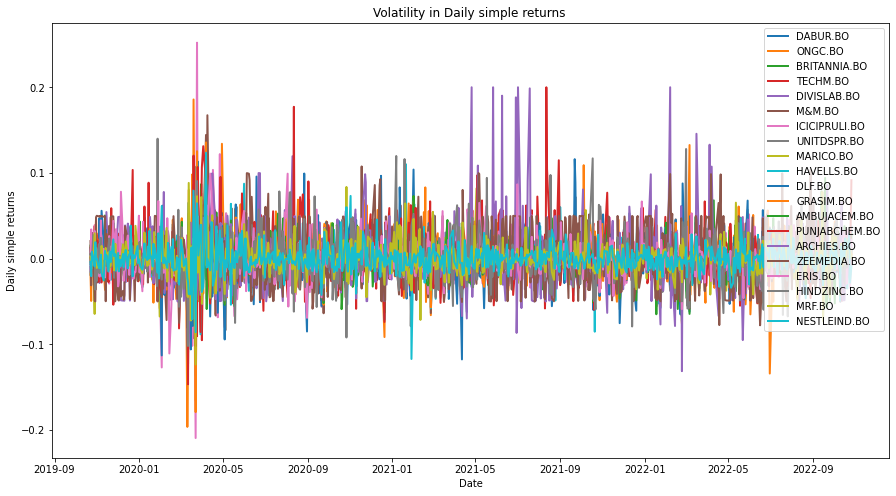

```python
daily_return = (data_1/data_1.shift())-1
daily_return.dropna(inplace=True)
fig, ax = plt.subplots(figsize=(15,8))
for i in daily_return.columns.values :
    ax.plot(daily_return[i], lw =2 ,label = i)


ax.legend( loc = 'upper right' , fontsize =10)
ax.set_title('Volatility in Daily simple returns ')
ax.set_xlabel('Date')
ax.set_ylabel('Daily simple returns')
plt.show(fig)
```

[figure not shown]

```python
print('Average Daily returns(%) of stocks in your portfolio')
Avg_daily = daily_return.mean()
print(Avg_daily*100)
```

```
Average Daily returns(%) of stocks in your portfolio
Symbols
DABUR.BO         0.032284
ONGC.BO          0.026835
BRITANNIA.BO     0.033609
TECHM.BO         0.077031
DIVISLAB.BO      0.116200
M&M.BO           0.131065
ICICIPRULI.BO    0.036611
UNITDSPR.BO      0.070526
MARICO.BO        0.050227
HAVELLS.BO       0.096782
DLF.BO           0.144283
GRASIM.BO        0.135523
AMBUJACEM.BO     0.154802
PUNJABCHEM.BO    0.157330
ARCHIES.BO       0.074305
ZEEMEDIA.BO      0.205230
ERIS.BO          0.092825
HINDZINC.BO      0.070300
MRF.BO           0.058013
NESTLEIND.BO     0.050858
dtype: float64
```

```python
high_low = data['High']- data ['Low']
high_closePrevious = np.abs(data['High'] - data ['Close'].shift())
low_closePrevious = np.abs(data['Low'] - data ['Close'].shift())
```

```python
# high_low
```

```python
# high_closePrevious
```

```python
# low_closePrevious
```

```python
df1 = pd.DataFrame(pd.concat([high_low,high_closePrevious,low_closePrevious],axis=1) )
```

```python
df1
```

| Symbols Date | DABUR.BO | ONGC.BO | BRITANNIA.BO | TECHM.BO | DIVISLAB.BO | M&M.BO | ICICIPRULI.BO | UNITDSPR.BO | MARICO.BO | HAVELLS.BO | ... | DLF.BO | GRASIM.BO | AMBUJACEM.BO | PUNJABCHEM.BO | ARCHIES.BO | ZEEMEDIA.BO | ERIS.BO | HINDZINC.BO | MRF.BO | NESTLEIND.BO |
| --- | --- | --- | --- | --- | --- | --- | --- | --- | --- | --- | --- | --- | --- | --- | --- | --- | --- | --- | --- | --- | --- |
| 2019-10-22 | 13.600006 | 3.699997 | 64.899902 | 16.849976 | 41.199951 | 13.750000 | 14.350006 | 37.200012 | 7.899994 | 21.500000 | ... | NaN | NaN | NaN | NaN | NaN | NaN | NaN | NaN | NaN | NaN |
| 2019-10-23 | 9.549988 | 3.599991 | 92.100098 | 17.400024 | 24.700073 | 12.600037 | 8.899994 | 9.800049 | 6.000000 | 23.450012 | ... | 4.250000 | 20.649963 | 2.550003 | 1.099976 | 0.400000 | 0.100000 | 8.899994 | 1.949997 | 196.050781 | 106.949219 |
| 2019-10-24 | 14.200012 | 3.050003 | 79.500000 | 19.899963 | 32.650024 | 16.000000 | 9.700012 | 18.099976 | 10.549988 | 23.050049 | ... | 0.100006 | 75.049988 | 2.300003 | 0.000000 | 0.450001 | 0.230000 | 1.149994 | 0.000000 | 1182.050781 | 356.349609 |
| 2019-10-25 | 11.350006 | 3.400009 | 53.350098 | 30.099976 | 27.449951 | 14.200012 | 13.450012 | 35.349976 | 9.399994 | 13.299988 | ... | 1.800003 | 16.899963 | 2.500000 | 4.750000 | 0.200001 | 0.200000 | 16.250000 | 1.199997 | 550.148438 | 205.200195 |
| 2019-10-27 | 2.949982 | 2.000000 | 67.100098 | 17.500000 | 23.400024 | 14.950012 | 5.299988 | 18.500000 | 9.700012 | 10.500000 | ... | 1.949997 | 15.799988 | 3.950012 | 6.599976 | 0.200001 | 0.020000 | 1.850006 | 3.150009 | 178.000000 | 15.899414 |
| ... | ... | ... | ... | ... | ... | ... | ... | ... | ... | ... | ... | ... | ... | ... | ... | ... | ... | ... | ... | ... | ... |
| 2022-10-20 | 14.849976 | 5.049995 | 53.349854 | 35.450012 | 90.600098 | 28.349976 | 27.250000 | 14.350037 | 10.500000 | 41.449951 | ... | 4.800018 | 16.849976 | 3.750000 | 5.300049 | 0.299999 | 0.300000 | 27.349976 | 4.350006 | 160.296875 | 85.451172 |
| 2022-10-21 | 7.200012 | 4.400009 | 49.300049 | 13.449951 | 104.000000 | 24.000000 | 14.699982 | 21.599976 | 10.900024 | 57.800049 | ... | 8.650024 | 19.050049 | 13.549988 | 37.750000 | 0.850000 | 0.300001 | 1.799988 | 0.449982 | 218.750000 | 24.650391 |
| 2022-10-24 | 6.400024 | 1.500000 | 108.050049 | 6.550049 | 43.949951 | 15.399902 | 6.300018 | 10.649963 | 5.450012 | 17.349976 | ... | 3.199982 | 16.950073 | 3.549988 | 17.899902 | 0.049999 | 0.400000 | 2.500000 | 0.600006 | 241.898438 | 64.750000 |
| 2022-10-25 | 7.200012 | 2.950012 | 113.400146 | 35.099976 | 51.899902 | 24.349976 | 10.299988 | 36.750000 | 7.849976 | 24.599976 | ... | 0.449982 | 5.400024 | 5.250000 | 20.250000 | 0.299999 | 0.150000 | 29.150024 | 2.450012 | 8.101562 | 648.650391 |
| 2022-10-27 | 14.599976 | 1.899994 | 65.899902 | 31.299927 | 31.700195 | 19.800049 | 20.649994 | 16.400024 | 6.299988 | 15.000000 | ... | 0.000000 | 0.550049 | 0.799988 | 12.300049 | 0.450001 | 0.600000 | 4.550049 | 0.600006 | 675.750000 | 365.650391 |

751 rows × 60 columns

```python
true_range = pd.DataFrame()
```

```python
for i in tickers:
    true_range[i] = np.max(df1[i],axis=1)
```

```python
true_range
```

| Date | DABUR.BO | ONGC.BO | BRITANNIA.BO | TECHM.BO | DIVISLAB.BO | M&M.BO | ICICIPRULI.BO | UNITDSPR.BO | MARICO.BO | HAVELLS.BO | DLF.BO | GRASIM.BO | AMBUJACEM.BO | PUNJABCHEM.BO | ARCHIES.BO | ZEEMEDIA.BO | ERIS.BO | HINDZINC.BO | MRF.BO | NESTLEIND.BO |
| --- | --- | --- | --- | --- | --- | --- | --- | --- | --- | --- | --- | --- | --- | --- | --- | --- | --- | --- | --- | --- |
| 2019-10-22 | 13.600006 | 3.699997 | 64.899902 | 16.849976 | 41.199951 | 13.750000 | 14.350006 | 37.200012 | 7.899994 | 21.500000 | 13.899994 | 31.750000 | 13.350006 | 10.500000 | 1.400000 | 0.540000 | 11.000000 | 10.500000 | 476.250000 | 273.000000 |
| 2019-10-23 | 9.549988 | 3.599991 | 95.149902 | 17.400024 | 24.700073 | 12.600037 | 8.899994 | 9.800049 | 6.000000 | 23.450012 | 4.650009 | 24.049988 | 4.699997 | 17.000000 | 0.500000 | 0.320000 | 9.549988 | 3.600006 | 503.949219 | 187.849609 |
| 2019-10-24 | 14.200012 | 3.050003 | 79.500000 | 19.899963 | 34.700073 | 16.000000 | 9.700012 | 18.099976 | 10.549988 | 23.050049 | 5.699997 | 75.049988 | 4.550003 | 0.000000 | 0.750000 | 0.230000 | 16.950012 | 4.500000 | 1497.949219 | 396.000000 |
| 2019-10-25 | 11.350006 | 3.400009 | 53.350098 | 30.099976 | 27.449951 | 14.200012 | 13.450012 | 35.349976 | 9.399994 | 15.150024 | 7.449997 | 26.649963 | 3.699997 | 16.500000 | 0.650000 | 0.400000 | 20.000000 | 3.949997 | 874.601562 | 425.950195 |
| 2019-10-27 | 5.549988 | 2.000000 | 67.100098 | 17.500000 | 23.400024 | 17.200012 | 5.299988 | 18.549988 | 9.700012 | 10.500000 | 3.300003 | 25.750000 | 5.600006 | 15.049988 | 0.600000 | 0.290000 | 5.899994 | 7.600006 | 586.601562 | 151.049805 |
| ... | ... | ... | ... | ... | ... | ... | ... | ... | ... | ... | ... | ... | ... | ... | ... | ... | ... | ... | ... | ... |
| 2022-10-20 | 14.849976 | 5.049995 | 53.349854 | 35.450012 | 90.600098 | 28.349976 | 27.250000 | 14.350037 | 10.500000 | 55.599976 | 9.149994 | 26.449951 | 12.200012 | 101.650024 | 0.950001 | 0.599999 | 41.000000 | 4.350006 | 1443.000000 | 460.800781 |
| 2022-10-21 | 7.200012 | 4.400009 | 49.300049 | 13.449951 | 104.000000 | 24.000000 | 14.699982 | 21.599976 | 10.900024 | 57.800049 | 10.050018 | 44.150024 | 18.799988 | 77.000000 | 1.150002 | 0.950001 | 27.849976 | 5.149994 | 3887.750000 | 314.849609 |
| 2022-10-24 | 6.400024 | 2.399994 | 108.050049 | 10.300049 | 60.149902 | 20.099976 | 7.750000 | 18.699951 | 5.500000 | 24.349976 | 7.850006 | 28.650024 | 9.099976 | 36.949951 | 2.500000 | 1.050001 | 16.149963 | 2.850006 | 2043.148438 | 776.800781 |
| 2022-10-25 | 7.200012 | 2.950012 | 113.400146 | 37.449951 | 51.899902 | 24.349976 | 10.500000 | 36.750000 | 7.849976 | 24.599976 | 8.299988 | 37.849976 | 10.000000 | 20.250000 | 0.699999 | 0.500000 | 29.400024 | 4.100006 | 1368.000000 | 785.199219 |
| 2022-10-27 | 19.000000 | 1.899994 | 65.899902 | 31.299927 | 31.700195 | 19.800049 | 20.649994 | 16.400024 | 6.299988 | 15.000000 | 15.350006 | 25.300049 | 19.500000 | 117.300049 | 0.600000 | 1.049999 | 18.050049 | 4.000000 | 1614.203125 | 565.949219 |

751 rows × 20 columns

```python
average_true_range = true_range.rolling(14).mean()
```

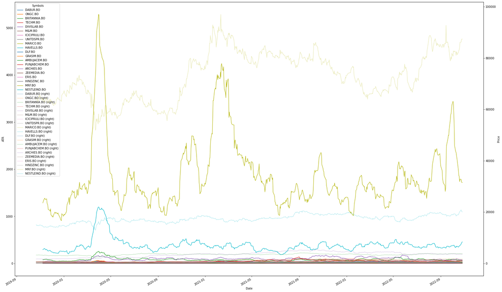

```python
# for i in tickers:
fig, ax = plt.subplots(figsize=(30,20))
average_true_range.plot(ax=ax)
ax2 = data_1.plot(ax=ax, secondary_y=True, alpha=.3)
ax.set_ylabel("ATR")
ax2.set_ylabel("Price")
```

[figure not shown]

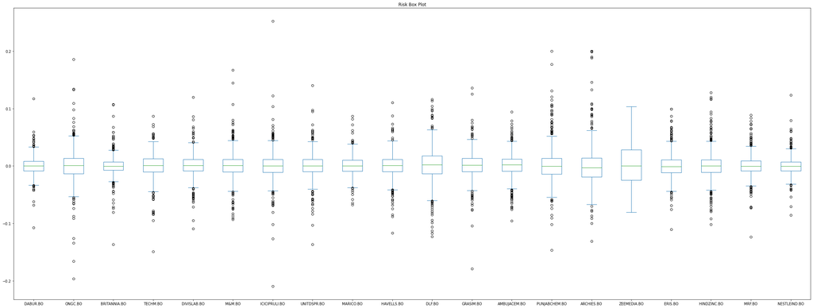

```python
daily_return.plot(kind = "box",figsize = (40,15), title = "Risk Box Plot")
```

[figure not shown]

```python
# Higher the Quartile range , higher the volatility , more the risk
# more Positive outliers, more is the return
```

```python
df2 = data['Adj Close']
```

```python
portfolio=[0.1,0.088,0.085,0.074,0.073,0.065,0.052,0.05,0.05,0.05,0.045,0.042,0.04,0.038,0.037,0.034,0.025,0.022,0.02,0.01]
```

```python
np.sum(portfolio)
```

```
1.0
```

```python
df2/df2.shift()
```

| Symbols Date | DABUR.BO | ONGC.BO | BRITANNIA.BO | TECHM.BO | DIVISLAB.BO | M&M.BO | ICICIPRULI.BO | UNITDSPR.BO | MARICO.BO | HAVELLS.BO | DLF.BO | GRASIM.BO | AMBUJACEM.BO | PUNJABCHEM.BO | ARCHIES.BO | ZEEMEDIA.BO | ERIS.BO | HINDZINC.BO | MRF.BO | NESTLEIND.BO |
| --- | --- | --- | --- | --- | --- | --- | --- | --- | --- | --- | --- | --- | --- | --- | --- | --- | --- | --- | --- | --- |
| 2019-10-22 | NaN | NaN | NaN | NaN | NaN | NaN | NaN | NaN | NaN | NaN | NaN | NaN | NaN | NaN | NaN | NaN | NaN | NaN | NaN | NaN |
| 2019-10-23 | 0.998836 | 0.984738 | 1.015215 | 1.012887 | 0.995639 | 0.990293 | 1.010522 | 1.012661 | 0.996331 | 0.993440 | 0.981201 | 0.982354 | 1.005107 | 1.001219 | 1.000000 | 1.020522 | 0.986235 | 1.000476 | 1.002368 | 0.996227 |
| 2019-10-24 | 0.995443 | 0.991194 | 0.997179 | 0.998418 | 1.017119 | 0.982001 | 0.989278 | 0.982738 | 1.002286 | 0.994064 | 1.009437 | 0.950686 | 1.005335 | 1.000000 | 0.978495 | 0.968921 | 1.034117 | 1.006427 | 0.987661 | 0.979633 |
| 2019-10-25 | 0.990844 | 0.991116 | 0.993900 | 0.992492 | 0.996317 | 0.995095 | 1.008233 | 1.030042 | 0.996833 | 0.992163 | 1.025212 | 1.004954 | 0.997473 | 1.009836 | 1.016483 | 1.030189 | 0.992617 | 0.999054 | 0.995393 | 1.008016 |
| 2019-10-27 | 1.008059 | 1.003586 | 0.997460 | 1.008953 | 1.000057 | 1.022570 | 1.003411 | 1.002231 | 0.995552 | 1.004664 | 0.991987 | 0.990282 | 1.001773 | 1.013265 | 1.016216 | 1.005494 | 1.010459 | 1.027462 | 0.999892 | 1.000909 |
| ... | ... | ... | ... | ... | ... | ... | ... | ... | ... | ... | ... | ... | ... | ... | ... | ... | ... | ... | ... | ... |
| 2022-10-20 | 1.017581 | 1.015662 | 1.006053 | 1.021389 | 1.011398 | 1.001442 | 1.021249 | 1.002594 | 1.011693 | 0.968278 | 1.008779 | 1.002195 | 1.013711 | 1.026458 | 1.017241 | 1.006211 | 0.970647 | 0.989520 | 1.012793 | 1.015186 |
| 2022-10-21 | 1.004016 | 1.013878 | 1.000488 | 1.000240 | 0.977611 | 1.005158 | 0.981505 | 0.987185 | 0.991403 | 0.965171 | 0.990896 | 0.991948 | 0.989759 | 1.029277 | 0.980630 | 0.990741 | 1.033279 | 1.008796 | 1.022980 | 1.011047 |
| 2022-10-24 | 0.999163 | 1.010266 | 1.003020 | 1.006531 | 1.011892 | 1.010900 | 1.004220 | 1.018284 | 1.001831 | 1.008186 | 0.993244 | 1.013191 | 1.009175 | 1.025926 | 1.007407 | 1.006231 | 1.008274 | 1.008007 | 1.000675 | 1.029182 |
| 2022-10-25 | 0.990691 | 0.983440 | 0.975992 | 1.032918 | 0.996650 | 1.008028 | 0.984265 | 1.033936 | 0.994230 | 0.999787 | 1.005986 | 1.010397 | 0.992359 | 0.992509 | 0.990196 | 1.003096 | 0.965887 | 1.002648 | 1.012862 | 0.971907 |
| 2022-10-27 | 1.032419 | 1.008037 | 1.011316 | 0.993164 | 1.006042 | 1.009682 | 0.993744 | 1.011462 | 1.004643 | 1.008631 | 1.037187 | 1.005131 | 1.028655 | 1.091524 | 0.997525 | 0.993827 | 1.022188 | 1.000176 | 1.000981 | 0.991105 |

751 rows × 20 columns

```python
log_returns = np.log(df2/df2.shift())
```

```python
log_returns
```

| Symbols Date | DABUR.BO | ONGC.BO | BRITANNIA.BO | TECHM.BO | DIVISLAB.BO | M&M.BO | ICICIPRULI.BO | UNITDSPR.BO | MARICO.BO | HAVELLS.BO | DLF.BO | GRASIM.BO | AMBUJACEM.BO | PUNJABCHEM.BO | ARCHIES.BO | ZEEMEDIA.BO | ERIS.BO | HINDZINC.BO | MRF.BO | NESTLEIND.BO |
| --- | --- | --- | --- | --- | --- | --- | --- | --- | --- | --- | --- | --- | --- | --- | --- | --- | --- | --- | --- | --- |
| 2019-10-22 | NaN | NaN | NaN | NaN | NaN | NaN | NaN | NaN | NaN | NaN | NaN | NaN | NaN | NaN | NaN | NaN | NaN | NaN | NaN | NaN |
| 2019-10-23 | -0.001165 | -0.015380 | 0.015100 | 0.012805 | -0.004371 | -0.009754 | 0.010467 | 0.012582 | -0.003676 | -0.006581 | -0.018978 | -0.017803 | 0.005094 | 0.001219 | 0.000000 | 0.020315 | -0.013860 | 0.000476 | 0.002365 | -0.003780 |
| 2019-10-24 | -0.004567 | -0.008845 | -0.002825 | -0.001583 | 0.016974 | -0.018163 | -0.010780 | -0.017413 | 0.002283 | -0.005953 | 0.009392 | -0.050571 | 0.005321 | 0.000000 | -0.021740 | -0.031572 | 0.033548 | 0.006406 | -0.012416 | -0.020578 |
| 2019-10-25 | -0.009198 | -0.008924 | -0.006119 | -0.007537 | -0.003690 | -0.004917 | 0.008199 | 0.029599 | -0.003173 | -0.007868 | 0.024900 | 0.004942 | -0.002530 | 0.009788 | 0.016349 | 0.029742 | -0.007410 | -0.000946 | -0.004617 | 0.007984 |
| 2019-10-27 | 0.008026 | 0.003579 | -0.002544 | 0.008914 | 0.000057 | 0.022319 | 0.003405 | 0.002229 | -0.004458 | 0.004653 | -0.008045 | -0.009765 | 0.001772 | 0.013178 | 0.016086 | 0.005479 | 0.010405 | 0.027092 | -0.000108 | 0.000909 |
| ... | ... | ... | ... | ... | ... | ... | ... | ... | ... | ... | ... | ... | ... | ... | ... | ... | ... | ... | ... | ... |
| 2022-10-20 | 0.017428 | 0.015540 | 0.006035 | 0.021164 | 0.011334 | 0.001441 | 0.021027 | 0.002590 | 0.011625 | -0.032236 | 0.008741 | 0.002193 | 0.013618 | 0.026114 | 0.017094 | 0.006192 | -0.029793 | -0.010535 | 0.012712 | 0.015072 |
| 2022-10-21 | 0.004008 | 0.013783 | 0.000488 | 0.000240 | -0.022644 | 0.005145 | -0.018668 | -0.012898 | -0.008634 | -0.035450 | -0.009146 | -0.008085 | -0.010293 | 0.028856 | -0.019561 | -0.009302 | 0.032737 | 0.008757 | 0.022720 | 0.010987 |
| 2022-10-24 | -0.000838 | 0.010214 | 0.003015 | 0.006509 | 0.011822 | 0.010841 | 0.004211 | 0.018119 | 0.001829 | 0.008152 | -0.006779 | 0.013104 | 0.009133 | 0.025596 | 0.007380 | 0.006211 | 0.008240 | 0.007975 | 0.000675 | 0.028764 |
| 2022-10-25 | -0.009353 | -0.016699 | -0.024301 | 0.032388 | -0.003356 | 0.007996 | -0.015860 | 0.033373 | -0.005787 | -0.000213 | 0.005968 | 0.010344 | -0.007670 | -0.007519 | -0.009852 | 0.003091 | -0.034709 | 0.002644 | 0.012780 | -0.028496 |
| 2022-10-27 | 0.031904 | 0.008005 | 0.011252 | -0.006859 | 0.006024 | 0.009635 | -0.006275 | 0.011396 | 0.004632 | 0.008594 | 0.036513 | 0.005118 | 0.028252 | 0.087575 | -0.002478 | -0.006192 | 0.021945 | 0.000176 | 0.000980 | -0.008935 |

751 rows × 20 columns

```python
log_return = np.sum(np.log(df2/df2.shift())*portfolio,axis=1)
```

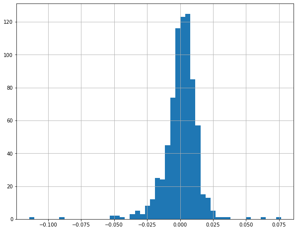

```python
fig, ax = plt.subplots(figsize=(10,8))
log_return.hist(bins=50, ax=ax)
```

[figure not shown]

```python
log_return.std()
```

```
0.012825210798756283
```

```python
log_return.mean()
```

```
0.0006377741645360946
```

```python
np.exp(log_return.mean())
```

```
1.000637977585722
```

```python
sharpe_ratio = (log_return.mean()-(0.0702/364))/log_return.std()
sharpe_ratio
```

```
0.03469081550863065
```

```python
asr = sharpe_ratio*(252**.5)
```

```python
asr
```

```
0.5506996236831563
```

```python
# information_ratio = (log_return.mean()-(0.112/252))/log_return.std()
information_ratio = (log_return.mean()-(0.1184/252))/log_return.std()
information_ratio
```

```
0.013093967602552775
```

```python
annual_infomation_ratio = information_ratio*(252**.5)
annual_infomation_ratio
```

```
0.20786029170894768
```

Monte Carlo Simulation

```python
n = 10000

weights = np.zeros((n, 20))
exp_returns = np.zeros(n)
exp_volumes = np.zeros(n)
sharpe_ratios = np.zeros(n)
information_ratios = np.zeros(n)

for i in range(n):
    weight = np.random.random(20)
    weight /= weight.sum()
    weights[i] = weight

    exp_returns[i] = np.sum(log_returns.mean()*weight)*252
    exp_volumes[i] = np.sqrt(np.dot(weight.T, np.dot(log_returns.cov()*252, weight)))
    sharpe_ratios[i] = (exp_returns[i]-(0.0702/364))/exp_volumes[i]
    # information_ratios[i] = (exp_returns[i]-(0.112/252))/exp_volumes[i]
    information_ratios[i] = (exp_returns[i]-(0.1184/252))/exp_volumes[i]
```

```python
sharpe_ratios.max()
```

```
1.0924558661464447
```

```python
sharpe_ratios.argmax()
```

```
7904
```

```python
information_ratios.max()
```

```
1.091208418342392
```

```python
information_ratios.argmax()
```

```
7904
```

```python
weights[sharpe_ratios.argmax()]      #Best weights for portfolio
```

```
array([4.19909381e-02, 8.14668216e-03, 7.52985840e-05, 6.04423362e-02,
       9.46064745e-02, 9.21240112e-02, 7.34633501e-03, 2.02236172e-02,
       4.85949369e-02, 1.22601282e-02, 9.23836360e-02, 8.58117553e-02,
       8.99728597e-02, 9.43288122e-02, 2.96618470e-03, 9.50087876e-02,
       1.72056787e-02, 8.48427188e-02, 8.04238893e-03, 4.36264201e-02])
```

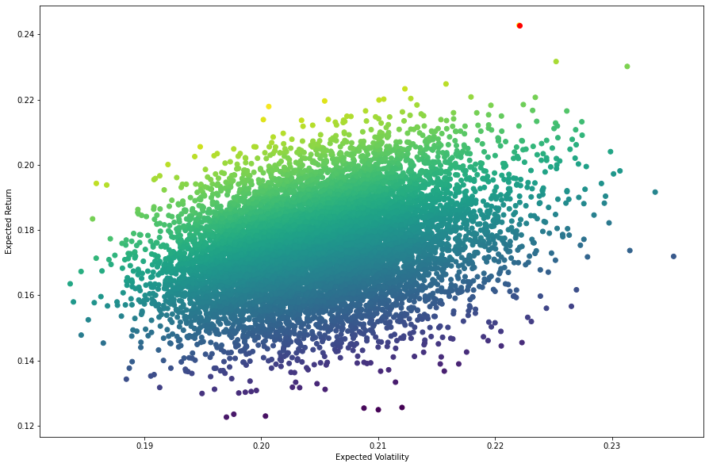

```python
fig, ax = plt.subplots(figsize = (15,10))
ax.scatter(exp_volumes, exp_returns, c=sharpe_ratios)
ax.scatter(exp_volumes[sharpe_ratios.argmax()], exp_returns[sharpe_ratios.argmax()], c='r')
ax.set_xlabel('Expected Volatility')
ax.set_ylabel('Expected Return')
```

[figure not shown]

```python
# Red dot shows the highest Sharpe ratio
```

```python
# fig, ax = plt.subplots(figsize = (15,10))
# ax.scatter(exp_volumes, exp_returns, c=sharpe_ratios)
# ax.scatter(exp_volumes[sharpe_ratios.argmax()], exp_returns[information_ratios.argmax()], c='r')
# ax.set_title('Information Ratio')
# ax.set_xlabel('Expected Volatility')
# ax.set_ylabel('Expected Return')
```

```python
exp_return = np.sum(log_returns.mean()*weights[sharpe_ratios.argmax()])*255
exp_volume = np.sqrt(np.dot(weights[sharpe_ratios.argmax()].T, np.dot(log_returns.cov()*255, weights[sharpe_ratios.argmax()])))
```

Correlation

```python
# log_returns.corr()
```

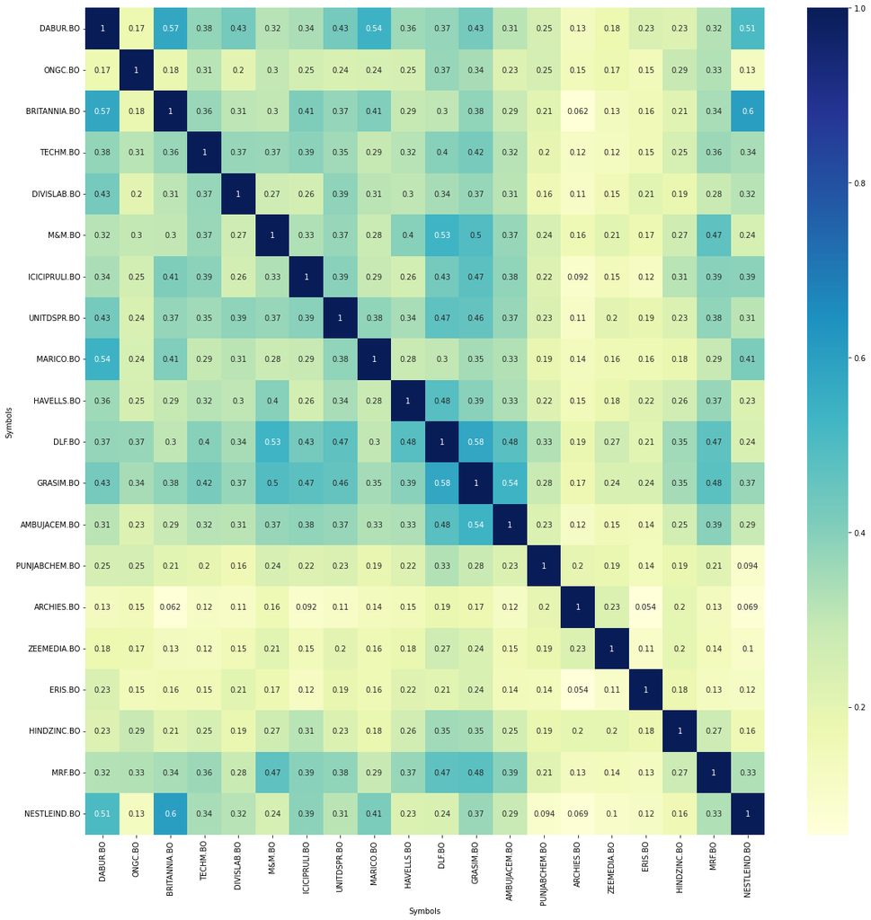

```python
fig1 = plt.figure(figsize=(20,20))
dataplot = sns.heatmap(log_returns.corr(),cmap='YlGnBu',annot= True)

plt.show(fig1)
```

[figure not shown]

```python
# INDEX = pdr.get_data_yahoo("^NSEI", start)
INDEX = pdr.get_data_yahoo("^BSESN", start)
```

```python
log_returns['INDEX'] = np.log(INDEX['Adj Close']/INDEX['Adj Close'].shift())
log_returns.dropna(inplace= True )
```

```python
# log_returns.corr()
```

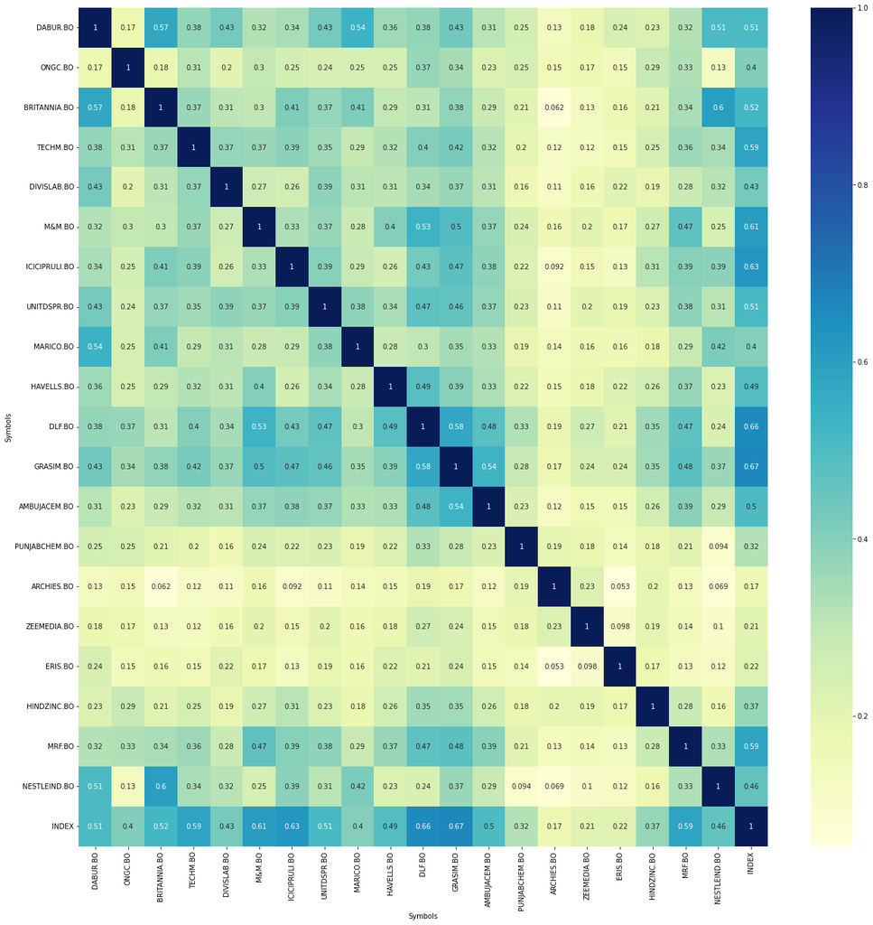

```python
fig2 = plt.figure(figsize=(22,22))
dataplot = sns.heatmap(log_returns.corr(),cmap='YlGnBu',annot= True)

plt.show(fig2)
```

[figure not shown]

Linear Regression

```python
# from sklearn.linear_model import LinearRegression
```

```python
# alphas = np.zeros(len(tickers))
# betas = np.zeros(len(tickers))
# def linear_regression(ticker_a,n):
#     X = log_returns[ticker_a].to_numpy().reshape(-1, 1)
#     Y = log_returns['N_INDEX'].to_numpy().reshape(-1, 1)
#     lin_regr = LinearRegression()
#     lin_regr.fit(X, Y)
#     Y_pred = lin_regr.predict(X)
#     alpha = lin_regr.intercept_[0]
#     beta = lin_regr.coef_[0, 0]
#     alphas[n]=round(alpha, 5)
#     betas[n]=round(beta, 3)
#     fig, ax = plt.subplots()
#     ax.set_title("Alpha: " + str(round(alpha, 5)) + ", Beta: " + str(round(beta, 3)))
#     ax.scatter(X, Y)
#     ax.plot(X, Y_pred, c='r')
```

```python
# for i in range (len(tickers)):
#     linear_regression(tickers[i],i)
```

Beta Calculations

```python
df2['INDEX'] = INDEX['Adj Close']
```

```python
log_rtns_n = np.log(df2/df2.shift())
```

```python
log_rtns_n
```

| Symbols Date | DABUR.BO | ONGC.BO | BRITANNIA.BO | TECHM.BO | DIVISLAB.BO | M&M.BO | ICICIPRULI.BO | UNITDSPR.BO | MARICO.BO | HAVELLS.BO | ... | GRASIM.BO | AMBUJACEM.BO | PUNJABCHEM.BO | ARCHIES.BO | ZEEMEDIA.BO | ERIS.BO | HINDZINC.BO | MRF.BO | NESTLEIND.BO | INDEX |
| --- | --- | --- | --- | --- | --- | --- | --- | --- | --- | --- | --- | --- | --- | --- | --- | --- | --- | --- | --- | --- | --- |
| 2019-10-22 | NaN | NaN | NaN | NaN | NaN | NaN | NaN | NaN | NaN | NaN | ... | NaN | NaN | NaN | NaN | NaN | NaN | NaN | NaN | NaN | NaN |
| 2019-10-23 | -0.001165 | -0.015380 | 0.015100 | 0.012805 | -0.004371 | -0.009754 | 0.010467 | 0.012582 | -0.003676 | -0.006581 | ... | -0.017803 | 0.005094 | 0.001219 | 0.000000 | 0.020315 | -0.013860 | 0.000476 | 0.002365 | -0.003780 | 0.002435 |
| 2019-10-24 | -0.004567 | -0.008845 | -0.002825 | -0.001583 | 0.016974 | -0.018163 | -0.010780 | -0.017413 | 0.002283 | -0.005953 | ... | -0.050571 | 0.005321 | 0.000000 | -0.021740 | -0.031572 | 0.033548 | 0.006406 | -0.012416 | -0.020578 | -0.000985 |
| 2019-10-25 | -0.009198 | -0.008924 | -0.006119 | -0.007537 | -0.003690 | -0.004917 | 0.008199 | 0.029599 | -0.003173 | -0.007868 | ... | 0.004942 | -0.002530 | 0.009788 | 0.016349 | 0.029742 | -0.007410 | -0.000946 | -0.004617 | 0.007984 | 0.000965 |
| 2019-10-27 | 0.008026 | 0.003579 | -0.002544 | 0.008914 | 0.000057 | 0.022319 | 0.003405 | 0.002229 | -0.004458 | 0.004653 | ... | -0.009765 | 0.001772 | 0.013178 | 0.016086 | 0.005479 | 0.010405 | 0.027092 | -0.000108 | 0.000909 | NaN |
| ... | ... | ... | ... | ... | ... | ... | ... | ... | ... | ... | ... | ... | ... | ... | ... | ... | ... | ... | ... | ... | ... |
| 2022-10-20 | 0.017428 | 0.015540 | 0.006035 | 0.021164 | 0.011334 | 0.001441 | 0.021027 | 0.002590 | 0.011625 | -0.032236 | ... | 0.002193 | 0.013618 | 0.026114 | 0.017094 | 0.006192 | -0.029793 | -0.010535 | 0.012712 | 0.015072 | 0.001618 |
| 2022-10-21 | 0.004008 | 0.013783 | 0.000488 | 0.000240 | -0.022644 | 0.005145 | -0.018668 | -0.012898 | -0.008634 | -0.035450 | ... | -0.008085 | -0.010293 | 0.028856 | -0.019561 | -0.009302 | 0.032737 | 0.008757 | 0.022720 | 0.010987 | 0.001759 |
| 2022-10-24 | -0.000838 | 0.010214 | 0.003015 | 0.006509 | 0.011822 | 0.010841 | 0.004211 | 0.018119 | 0.001829 | 0.008152 | ... | 0.013104 | 0.009133 | 0.025596 | 0.007380 | 0.006211 | 0.008240 | 0.007975 | 0.000675 | 0.028764 | 0.008805 |
| 2022-10-25 | -0.009353 | -0.016699 | -0.024301 | 0.032388 | -0.003356 | 0.007996 | -0.015860 | 0.033373 | -0.005787 | -0.000213 | ... | 0.010344 | -0.007670 | -0.007519 | -0.009852 | 0.003091 | -0.034709 | 0.002644 | 0.012780 | -0.028496 | -0.004820 |
| 2022-10-27 | 0.031904 | 0.008005 | 0.011252 | -0.006859 | 0.006024 | 0.009635 | -0.006275 | 0.011396 | 0.004632 | 0.008594 | ... | 0.005118 | 0.028252 | 0.087575 | -0.002478 | -0.006192 | 0.021945 | 0.000176 | 0.000980 | -0.008935 | 0.003569 |

751 rows × 21 columns

```python
cov = log_rtns_n.cov()
```

```python
var = log_rtns_n['INDEX'].var()
```

```python
var
```

```
0.0002129224579051995
```

```python
# cov.loc['ITC.NS', 'INDEX']/var
```

```python
cov.loc['INDEX']/var
```

```
Symbols
DABUR.BO         0.548306
ONGC.BO          0.755639
BRITANNIA.BO     0.605693
TECHM.BO         0.872371
DIVISLAB.BO      0.565523
M&M.BO           0.987698
ICICIPRULI.BO    1.070895
UNITDSPR.BO      0.765484
MARICO.BO        0.465963
HAVELLS.BO       0.716358
DLF.BO           1.311238
GRASIM.BO        1.040115
AMBUJACEM.BO     0.733676
PUNJABCHEM.BO    0.644324
ARCHIES.BO       0.404315
ZEEMEDIA.BO      0.501864
ERIS.BO          0.296177
HINDZINC.BO      0.602612
MRF.BO           0.734968
NESTLEIND.BO     0.494389
INDEX            1.000000
Name: INDEX, dtype: float64
```

```python
# beta_itc=cov.loc['ITC.NS', 'INDEX']/var
```

CAPM(Capital Asset Pricing Model)

```python
risk_free_return=0.0702
market_return=0.112
# market_return=0.1184
# expected_return = risk_free_return + beta_itc*(market_return - risk_free_return)
```

```python
# expected_return
```

```python
beta = cov.loc['INDEX']/var
```

```python
beta.mean()
```

```
0.7198861342476385
```

```python
expected_return = risk_free_return + beta*(market_return - risk_free_return)
```

```python
expected_return
```

```
Symbols
DABUR.BO         0.093119
ONGC.BO          0.101786
BRITANNIA.BO     0.095518
TECHM.BO         0.106665
DIVISLAB.BO      0.093839
M&M.BO           0.111486
ICICIPRULI.BO    0.114963
UNITDSPR.BO      0.102197
MARICO.BO        0.089677
HAVELLS.BO       0.100144
DLF.BO           0.125010
GRASIM.BO        0.113677
AMBUJACEM.BO     0.100868
PUNJABCHEM.BO    0.097133
ARCHIES.BO       0.087100
ZEEMEDIA.BO      0.091178
ERIS.BO          0.082580
HINDZINC.BO      0.095389
MRF.BO           0.100922
NESTLEIND.BO     0.090865
INDEX            0.112000
Name: INDEX, dtype: float64
```

```python
expected_return.mean()
```

```
0.1002912404115513
```

Jensen's Alpha

```
    Average_portfolio_return-CAPM(expected_return)
```

```python
Jensen= exp_return-expected_return.mean()
Jensen
```

```
0.14536126180370543
```

Treynor's Ratio

```
    (Average_portfolio_return-risk_free_rate)/beta
```

```python
treynor= (exp_return-risk_free_return)/beta.mean()
treynor
```

```
0.24372257481889717
```

Mordern Portfolio Theory (Markovitz Portfolio Theory)

```python
returns = data_1.pct_change()
mean_returns = returns.mean()
cov_matrix = returns.cov()
num_portfolios = 10000
risk_free_rate = 0.0702
```

```python
def portfolio_annualised_performance(weights, mean_returns, cov_matrix):
    returns = np.sum(mean_returns*weights ) *252
    std = np.sqrt(np.dot(weights.T, np.dot(cov_matrix, weights))) * np.sqrt(252)
    return std, returns
```

```python
def random_portfolios(num_portfolios, mean_returns, cov_matrix, risk_free_rate):
    results = np.zeros((3,num_portfolios))
    weights_record = []
    for i in range(num_portfolios):
        weights = np.random.random(20)
        weights /= np.sum(weights)
        weights_record.append(weights)
        portfolio_std_dev, portfolio_return = portfolio_annualised_performance(weights, mean_returns, cov_matrix)
        results[0,i] = portfolio_std_dev
        results[1,i] = portfolio_return
        results[2,i] = (portfolio_return - risk_free_rate) / portfolio_std_dev
    return results, weights_record
```

```python
def display_simulated_ef_with_random(mean_returns, cov_matrix, num_portfolios, risk_free_rate):
    results, weights = random_portfolios(num_portfolios,mean_returns, cov_matrix, risk_free_rate)

    max_sharpe_idx = np.argmax(results[2])
    sdp, rp = results[0,max_sharpe_idx], results[1,max_sharpe_idx]
    max_sharpe_allocation = pd.DataFrame(weights[max_sharpe_idx],index=data_1.columns,columns=['allocation'])
    max_sharpe_allocation.allocation = [round(i*100,2)for i in max_sharpe_allocation.allocation]
    max_sharpe_allocation = max_sharpe_allocation.T

    min_vol_idx = np.argmin(results[0])
    sdp_min, rp_min = results[0,min_vol_idx], results[1,min_vol_idx]
    min_vol_allocation = pd.DataFrame(weights[min_vol_idx],index=data_1.columns,columns=['allocation'])
    min_vol_allocation.allocation = [round(i*100,2)for i in min_vol_allocation.allocation]
    min_vol_allocation = min_vol_allocation.T

    print ("-"*80)
    print ("Maximum Sharpe Ratio Portfolio Allocation\n")
    print ("Annualised Return:", round(rp,2))
    print ("Annualised Volatility:", round(sdp,2))
    print ("\n")
    print (max_sharpe_allocation)
    print ("-"*80)
    print ("Minimum Volatility Portfolio Allocation\n")
    print ("Annualised Return:", round(rp_min,2))
    print ("Annualised Volatility:", round(sdp_min,2))
    print ("\n")
    print (min_vol_allocation)

    plt.figure(figsize=(10, 7))
    plt.scatter(results[0,:],results[1,:],c=results[2,:],cmap='YlGnBu', marker='o', s=10, alpha=0.3)
    plt.colorbar()
    plt.scatter(sdp,rp,marker='*',color='r',s=500, label='Maximum Sharpe ratio')
    plt.scatter(sdp_min,rp_min,marker='*',color='g',s=500, label='Minimum volatility')
    plt.title('Simulated Portfolio Optimization based on Efficient Frontier')
    plt.xlabel('annualised volatility')
    plt.ylabel('annualised returns')
    plt.legend(labelspacing=0.8)
```

```
--------------------------------------------------------------------------------
Maximum Sharpe Ratio Portfolio Allocation

Annualised Return: 0.3
Annualised Volatility: 0.22


Symbols     DABUR.BO  ONGC.BO  BRITANNIA.BO  TECHM.BO  DIVISLAB.BO  M&M.BO  \
allocation      3.97      2.5          2.58      5.41         4.58    0.43

Symbols     ICICIPRULI.BO  UNITDSPR.BO  MARICO.BO  HAVELLS.BO  DLF.BO  \
allocation           0.82         0.02       0.48        0.69    6.38

Symbols     GRASIM.BO  AMBUJACEM.BO  PUNJABCHEM.BO  ARCHIES.BO  ZEEMEDIA.BO  \
allocation      12.93         10.32          10.88        5.14        12.72

Symbols     ERIS.BO  HINDZINC.BO  MRF.BO  NESTLEIND.BO
allocation     7.95         0.68    2.59          8.93
--------------------------------------------------------------------------------
Minimum Volatility Portfolio Allocation

Annualised Return: 0.22
Annualised Volatility: 0.18


Symbols     DABUR.BO  ONGC.BO  BRITANNIA.BO  TECHM.BO  DIVISLAB.BO  M&M.BO  \
allocation      9.78      2.4          9.74      4.71        10.71    4.81

Symbols     ICICIPRULI.BO  UNITDSPR.BO  MARICO.BO  HAVELLS.BO  DLF.BO  \
allocation           1.01         1.96       6.11        4.53    0.49

Symbols     GRASIM.BO  AMBUJACEM.BO  PUNJABCHEM.BO  ARCHIES.BO  ZEEMEDIA.BO  \
allocation       4.15          7.02           1.94        0.02         3.53

Symbols     ERIS.BO  HINDZINC.BO  MRF.BO  NESTLEIND.BO
allocation    11.25         1.92    5.91          8.01
```

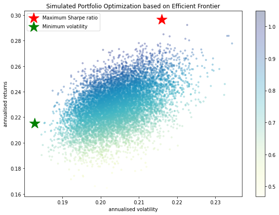

```python
display_simulated_ef_with_random(mean_returns, cov_matrix, num_portfolios, risk_free_rate)
```

Maximum Sharpe Ratio Portfolio Allocation

Annualised Return: 0.5 Annualised Volatility: 0.22

Symbols ITC.NS AMBUJACEM.NS ADANIPORTS.NS SBIN.NS LT.NS PATANJALI.NS  
allocation 6.92 6.37 1.1 5.3 4.02 11.42

Symbols IRB.NS FORTIS.NS LINDEINDIA.NS ESCORTS.NS ZEEL.NS CRISIL.NS  
allocation 0.38 5.9 12.19 6.84 1.71 11.36

Symbols KOTAKBANK.NS AEGISCHEM.NS HFCL.NS SUNPHARMA.NS TATACOMM.NS  
allocation 0.21 0.3 5.27 7.07 7.99

Symbols RELIANCE.NS IPL.NS CUMMINSIND.NS  
allocation 0.5 2.37 2.79

Minimum Volatility Portfolio Allocation

Annualised Return: 0.33 Annualised Volatility: 0.2

Symbols ITC.NS AMBUJACEM.NS ADANIPORTS.NS SBIN.NS LT.NS PATANJALI.NS  
allocation 6.84 6.79 0.43 0.16 8.56 3.13

Symbols IRB.NS FORTIS.NS LINDEINDIA.NS ESCORTS.NS ZEEL.NS CRISIL.NS  
allocation 3.21 5.75 5.03 2.11 3.3 6.86

Symbols KOTAKBANK.NS AEGISCHEM.NS HFCL.NS SUNPHARMA.NS TATACOMM.NS  
allocation 8.91 7.33 0.41 7.81 6.58

Symbols RELIANCE.NS IPL.NS CUMMINSIND.NS  
allocation 3.06 4.8 8.92

[figure not shown]

Maximum Sharpe Ratio Portfolio Allocation

Annualised Return: 0.25 Annualised Volatility: 0.23

Symbols KOTAKBANK.NS TATAMOTORS.NS GRASIM.NS COALINDIA.NS SHREECEM.NS \ allocation 0.86 11.0 6.97 5.18 5.01

Symbols EICHERMOT.NS AXISBANK.NS SBIN.NS IOC.NS BPCL.NS UPL.NS \ allocation 11.97 1.85 5.53 0.38 2.68 0.39

Symbols MARUTI.NS SUNPHARMA.NS ONGC.NS BRITANNIA.NS ADANIPORTS.NS \ allocation 0.94 13.03 0.02 11.55 7.97

Symbols NESTLEIND.NS TATASTEEL.NS DRREDDY.NS  
allocation 3.64 1.06 9.96

Minimum Volatility Portfolio Allocation

Annualised Return: 0.17 Annualised Volatility: 0.21

Symbols KOTAKBANK.NS TATAMOTORS.NS GRASIM.NS COALINDIA.NS SHREECEM.NS \ allocation 6.63 0.91 5.42 4.19 9.47

Symbols EICHERMOT.NS AXISBANK.NS SBIN.NS IOC.NS BPCL.NS UPL.NS \ allocation 7.91 1.09 0.16 7.63 1.79 7.01

Symbols MARUTI.NS SUNPHARMA.NS ONGC.NS BRITANNIA.NS ADANIPORTS.NS \ allocation 4.31 10.07 2.47 7.54 0.35

Symbols NESTLEIND.NS TATASTEEL.NS DRREDDY.NS  
allocation 8.56 3.28 11.2

[figure not shown]

Maximum Sharpe Ratio Portfolio Allocation

Annualised Return: 0.87 Annualised Volatility: 0.19

Symbols BOMOXY-B1.BO AXISBANK.BO IKAB.BO JPOLYINVST.BO ICRA.BO \ allocation 1.22 1.74 10.25 9.75 1.88

Symbols KOTAKBANK.BO DHUNINV.BO SBILIFE.BO PILANIINVS.BO ICICIBANK.BO \ allocation 4.26 4.26 0.54 5.08 1.85

Symbols THACKER.BO ORACLECR.BO JINDALPHOT.BO CGCL.BO CANBK.BO \ allocation 6.61 8.64 9.73 10.52 0.43

Symbols MONARCH.BO SUMEDHA.BO SYSTMTXC.BO INDOTHAI.BO SILINV.BO  
allocation 5.81 3.53 6.21 6.72 0.96

Minimum Volatility Portfolio Allocation

Annualised Return: 0.66 Annualised Volatility: 0.17

Symbols BOMOXY-B1.BO AXISBANK.BO IKAB.BO JPOLYINVST.BO ICRA.BO \ allocation 6.82 2.99 9.23 8.13 6.51

Symbols KOTAKBANK.BO DHUNINV.BO SBILIFE.BO PILANIINVS.BO ICICIBANK.BO \ allocation 7.9 0.61 8.38 3.91 2.8

Symbols THACKER.BO ORACLECR.BO JINDALPHOT.BO CGCL.BO CANBK.BO \ allocation 6.72 6.8 5.15 7.06 1.44

Symbols MONARCH.BO SUMEDHA.BO SYSTMTXC.BO INDOTHAI.BO SILINV.BO  
allocation 2.49 2.54 5.34 2.71 2.46

[figure not shown]

Maximum Sharpe Ratio Portfolio Allocation

Annualised Return: 0.29 Annualised Volatility: 0.19

Symbols SUNPHARMA.BO DRREDDY.BO DIVISLAB.BO CIPLA.BO BIOCON.BO \ allocation 10.91 4.77 6.33 6.71 2.89

Symbols TORNTPHARM.BO AUROPHARMA.BO LUPIN.BO ABBOTINDIA.BO ALKEM.BO \ allocation 2.91 1.84 0.07 3.7 8.44

Symbols APOLLOHOSP.BO IPCALAB.BO GLAXO.BO PFIZER.BO SYNGENE.BO \ allocation 7.79 0.5 6.87 6.21 10.68

Symbols APLLTD.BO SANOFI.BO LALPATHLAB.BO LAURUSLABS.BO NATCOPHARM.BO  
allocation 2.7 0.57 3.26 11.14 1.71

Minimum Volatility Portfolio Allocation

Annualised Return: 0.19 Annualised Volatility: 0.17

Symbols SUNPHARMA.BO DRREDDY.BO DIVISLAB.BO CIPLA.BO BIOCON.BO \ allocation 7.59 9.69 2.97 1.39 2.75

Symbols TORNTPHARM.BO AUROPHARMA.BO LUPIN.BO ABBOTINDIA.BO ALKEM.BO \ allocation 4.47 1.09 1.43 7.33 8.92

Symbols APOLLOHOSP.BO IPCALAB.BO GLAXO.BO PFIZER.BO SYNGENE.BO \ allocation 3.88 3.81 5.18 9.58 9.71

Symbols APLLTD.BO SANOFI.BO LALPATHLAB.BO LAURUSLABS.BO NATCOPHARM.BO  
allocation 1.38 10.3 4.86 1.42 2.26

[figure not shown]

```python
def neg_sharpe_ratio(weights, mean_returns, cov_matrix, risk_free_rate):
    p_var, p_ret = portfolio_annualised_performance(weights, mean_returns, cov_matrix)
    return -(p_ret - risk_free_rate) / p_var

def max_sharpe_ratio(mean_returns, cov_matrix, risk_free_rate):
    num_assets = len(mean_returns)
    args = (mean_returns, cov_matrix, risk_free_rate)
    constraints = ({'type': 'eq', 'fun': lambda x: np.sum(x) - 1})
    bound = (0.0,1.0)
    bounds = tuple(bound for asset in range(num_assets))
    result = sco.minimize(neg_sharpe_ratio, num_assets*[1./num_assets,], args=args,
                        method='SLSQP', bounds=bounds, constraints=constraints)
    return result
```

```python
def portfolio_volatility(weights, mean_returns, cov_matrix):
    return portfolio_annualised_performance(weights, mean_returns, cov_matrix)[0]

def min_variance(mean_returns, cov_matrix):
    num_assets = len(mean_returns)
    args = (mean_returns, cov_matrix)
    constraints = ({'type': 'eq', 'fun': lambda x: np.sum(x) - 1})
    bound = (0.0,1.0)
    bounds = tuple(bound for asset in range(num_assets))

    result = sco.minimize(portfolio_volatility, num_assets*[1./num_assets,], args=args,
                        method='SLSQP', bounds=bounds, constraints=constraints)

    return result
```

```python
def efficient_return(mean_returns, cov_matrix, target):
    num_assets = len(mean_returns)
    args = (mean_returns, cov_matrix)

    def portfolio_return(weights):
        return portfolio_annualised_performance(weights, mean_returns, cov_matrix)[1]

    constraints = ({'type': 'eq', 'fun': lambda x: portfolio_return(x) - target},
                   {'type': 'eq', 'fun': lambda x: np.sum(x) - 1})
    bounds = tuple((0,1) for asset in range(num_assets))
    result = sco.minimize(portfolio_volatility, num_assets*[1./num_assets,], args=args, method='SLSQP', bounds=bounds, constraints=constraints)
    return result


def efficient_frontier(mean_returns, cov_matrix, returns_range):
    efficients = []
    for ret in returns_range:
        efficients.append(efficient_return(mean_returns, cov_matrix, ret))
    return efficients
```

```python
def display_calculated_ef_with_random(mean_returns, cov_matrix, num_portfolios, risk_free_rate):
    results, _ = random_portfolios(num_portfolios,mean_returns, cov_matrix, risk_free_rate)

    max_sharpe = max_sharpe_ratio(mean_returns, cov_matrix, risk_free_rate)
    sdp, rp = portfolio_annualised_performance(max_sharpe['x'], mean_returns, cov_matrix)
    max_sharpe_allocation = pd.DataFrame(max_sharpe.x,index=data_1.columns,columns=['allocation'])
    max_sharpe_allocation.allocation = [round(i*100,2)for i in max_sharpe_allocation.allocation]
    max_sharpe_allocation = max_sharpe_allocation.T
    max_sharpe_allocation

    min_vol = min_variance(mean_returns, cov_matrix)
    sdp_min, rp_min = portfolio_annualised_performance(min_vol['x'], mean_returns, cov_matrix)
    min_vol_allocation = pd.DataFrame(min_vol.x,index=data_1.columns,columns=['allocation'])
    min_vol_allocation.allocation = [round(i*100,2)for i in min_vol_allocation.allocation]
    min_vol_allocation = min_vol_allocation.T

    print ("-"*80)
    print ("Maximum Sharpe Ratio Portfolio Allocation\n")
    print ("Annualised Return:", round(rp,2))
    print ("Annualised Volatility:", round(sdp,2))
    print ("\n")
    print (max_sharpe_allocation)
    print ("-"*80)
    print ("Minimum Volatility Portfolio Allocation\n")
    print ("Annualised Return:", round(rp_min,2))
    print ("Annualised Volatility:", round(sdp_min,2))
    print ("\n")
    print (min_vol_allocation)

    plt.figure(figsize=(10, 7))
    plt.scatter(results[0,:],results[1,:],c=results[2,:],cmap='YlGnBu', marker='o', s=10, alpha=0.3)
    plt.colorbar()
    plt.scatter(sdp,rp,marker='*',color='r',s=500, label='Maximum Sharpe ratio')
    plt.scatter(sdp_min,rp_min,marker='*',color='g',s=500, label='Minimum volatility')

    target = np.linspace(rp_min, 0.32, 50)
    efficient_portfolios = efficient_frontier(mean_returns, cov_matrix, target)
    plt.plot([p['fun'] for p in efficient_portfolios], target, linestyle='-.', color='black', label='efficient frontier')
    plt.title('Calculated Portfolio Optimization based on Efficient Frontier')
    plt.xlabel('annualised volatility')
    plt.ylabel('annualised returns')
    plt.legend(labelspacing=0.8)
```

```
--------------------------------------------------------------------------------
Maximum Sharpe Ratio Portfolio Allocation

Annualised Return: 0.37
Annualised Volatility: 0.23


Symbols     DABUR.BO  ONGC.BO  BRITANNIA.BO  TECHM.BO  DIVISLAB.BO  M&M.BO  \
allocation       0.0      0.0           0.0       0.0        17.97    6.89

Symbols     ICICIPRULI.BO  UNITDSPR.BO  MARICO.BO  HAVELLS.BO  DLF.BO  \
allocation            0.0          0.0        0.0         0.0     0.0

Symbols     GRASIM.BO  AMBUJACEM.BO  PUNJABCHEM.BO  ARCHIES.BO  ZEEMEDIA.BO  \
allocation        0.0         32.08           12.9         0.0        18.27

Symbols     ERIS.BO  HINDZINC.BO  MRF.BO  NESTLEIND.BO
allocation     11.9          0.0     0.0           0.0
--------------------------------------------------------------------------------
Minimum Volatility Portfolio Allocation

Annualised Return: 0.19
Annualised Volatility: 0.17


Symbols     DABUR.BO  ONGC.BO  BRITANNIA.BO  TECHM.BO  DIVISLAB.BO  M&M.BO  \
allocation      5.78     0.35          5.55      1.48         7.11     0.0

Symbols     ICICIPRULI.BO  UNITDSPR.BO  MARICO.BO  HAVELLS.BO  DLF.BO  \
allocation            0.0          0.0      12.97         2.7     0.0

Symbols     GRASIM.BO  AMBUJACEM.BO  PUNJABCHEM.BO  ARCHIES.BO  ZEEMEDIA.BO  \
allocation        0.0           3.5           2.83        3.28         2.06

Symbols     ERIS.BO  HINDZINC.BO  MRF.BO  NESTLEIND.BO
allocation     16.0         5.77   10.42         20.23
```

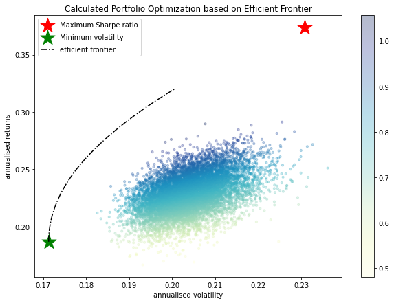

```python
display_calculated_ef_with_random(mean_returns, cov_matrix, num_portfolios, risk_free_rate)
```

Maximum Sharpe Ratio Portfolio Allocation

Annualised Return: 0.69 Annualised Volatility: 0.27

Symbols ITC.NS AMBUJACEM.NS ADANIPORTS.NS SBIN.NS LT.NS PATANJALI.NS \ allocation 0.0 8.25 0.0 0.0 0.0 21.15

Symbols IRB.NS FORTIS.NS LINDEINDIA.NS ESCORTS.NS ZEEL.NS CRISIL.NS \ allocation 4.05 2.13 24.88 9.1 0.0 6.23

Symbols KOTAKBANK.NS AEGISCHEM.NS HFCL.NS SUNPHARMA.NS TATACOMM.NS \ allocation 0.0 0.0 4.67 6.56 12.97

Symbols RELIANCE.NS IPL.NS CUMMINSIND.NS  
allocation 0.0 0.0 0.0

Minimum Volatility Portfolio Allocation

Annualised Return: 0.3 Annualised Volatility: 0.19

Symbols ITC.NS AMBUJACEM.NS ADANIPORTS.NS SBIN.NS LT.NS PATANJALI.NS \ allocation 15.88 6.51 0.0 0.0 0.0 3.52

Symbols IRB.NS FORTIS.NS LINDEINDIA.NS ESCORTS.NS ZEEL.NS CRISIL.NS \ allocation 0.0 11.17 1.76 0.0 0.0 13.23

Symbols KOTAKBANK.NS AEGISCHEM.NS HFCL.NS SUNPHARMA.NS TATACOMM.NS \ allocation 6.75 0.17 0.0 15.19 3.83

Symbols RELIANCE.NS IPL.NS CUMMINSIND.NS  
allocation 4.28 6.27 11.45

[figure not shown]

Maximum Sharpe Ratio Portfolio Allocation

Annualised Return: 0.4 Annualised Volatility: 0.29

Symbols KOTAKBANK.NS TATAMOTORS.NS GRASIM.NS COALINDIA.NS SHREECEM.NS \ allocation 0.0 18.87 4.68 0.0 0.0

Symbols EICHERMOT.NS AXISBANK.NS SBIN.NS IOC.NS BPCL.NS UPL.NS \ allocation 4.12 0.0 0.0 0.0 0.0 0.0

Symbols MARUTI.NS SUNPHARMA.NS ONGC.NS BRITANNIA.NS ADANIPORTS.NS \ allocation 0.0 50.28 0.0 0.0 0.0

Symbols NESTLEIND.NS TATASTEEL.NS DRREDDY.NS  
allocation 0.0 22.05 0.0

Minimum Volatility Portfolio Allocation

Annualised Return: 0.12 Annualised Volatility: 0.18

Symbols KOTAKBANK.NS TATAMOTORS.NS GRASIM.NS COALINDIA.NS SHREECEM.NS \ allocation 6.31 0.0 0.0 6.1 1.16

Symbols EICHERMOT.NS AXISBANK.NS SBIN.NS IOC.NS BPCL.NS UPL.NS \ allocation 4.88 0.0 0.0 16.96 0.0 0.0

Symbols MARUTI.NS SUNPHARMA.NS ONGC.NS BRITANNIA.NS ADANIPORTS.NS \ allocation 0.0 8.9 0.0 11.29 0.0

Symbols NESTLEIND.NS TATASTEEL.NS DRREDDY.NS  
allocation 27.38 0.0 17.03

[figure not shown]

Maximum Sharpe Ratio Portfolio Allocation

Annualised Return: 1.12 Annualised Volatility: 0.2

Symbols BOMOXY-B1.BO AXISBANK.BO IKAB.BO JPOLYINVST.BO ICRA.BO \ allocation 0.0 0.0 28.13 13.02 2.75

Symbols KOTAKBANK.BO DHUNINV.BO SBILIFE.BO PILANIINVS.BO ICICIBANK.BO \ allocation 0.0 1.57 0.0 0.0 0.0

Symbols THACKER.BO ORACLECR.BO JINDALPHOT.BO CGCL.BO CANBK.BO \ allocation 5.67 15.07 5.81 6.37 0.0

Symbols MONARCH.BO SUMEDHA.BO SYSTMTXC.BO INDOTHAI.BO SILINV.BO  
allocation 4.86 5.0 7.41 4.34 0.0

Minimum Volatility Portfolio Allocation

Annualised Return: 0.59 Annualised Volatility: 0.15

Symbols BOMOXY-B1.BO AXISBANK.BO IKAB.BO JPOLYINVST.BO ICRA.BO \ allocation 6.53 0.0 11.88 4.6 16.35

Symbols KOTAKBANK.BO DHUNINV.BO SBILIFE.BO PILANIINVS.BO ICICIBANK.BO \ allocation 6.38 1.48 12.48 2.99 0.0

Symbols THACKER.BO ORACLECR.BO JINDALPHOT.BO CGCL.BO CANBK.BO \ allocation 9.66 7.32 0.99 8.16 0.0

Symbols MONARCH.BO SUMEDHA.BO SYSTMTXC.BO INDOTHAI.BO SILINV.BO  
allocation 0.0 1.94 7.39 1.86 0.0

[figure not shown]

Maximum Sharpe Ratio Portfolio Allocation

Annualised Return: 0.55 Annualised Volatility: 0.29

Symbols SUNPHARMA.BO DRREDDY.BO DIVISLAB.BO CIPLA.BO BIOCON.BO \ allocation 3.46 0.0 0.0 23.19 0.0

Symbols TORNTPHARM.BO AUROPHARMA.BO LUPIN.BO ABBOTINDIA.BO ALKEM.BO \ allocation 0.0 0.0 0.0 1.36 0.0

Symbols APOLLOHOSP.BO IPCALAB.BO GLAXO.BO PFIZER.BO SYNGENE.BO \ allocation 18.19 1.78 0.0 0.0 0.0

Symbols APLLTD.BO SANOFI.BO LALPATHLAB.BO LAURUSLABS.BO NATCOPHARM.BO  
allocation 0.0 0.0 3.16 48.87 0.0

Minimum Volatility Portfolio Allocation

Annualised Return: 0.13 Annualised Volatility: 0.16

Symbols SUNPHARMA.BO DRREDDY.BO DIVISLAB.BO CIPLA.BO BIOCON.BO \ allocation 1.11 6.36 0.0 2.68 0.0

Symbols TORNTPHARM.BO AUROPHARMA.BO LUPIN.BO ABBOTINDIA.BO ALKEM.BO \ allocation 0.31 0.0 0.0 7.5 12.13

Symbols APOLLOHOSP.BO IPCALAB.BO GLAXO.BO PFIZER.BO SYNGENE.BO \ allocation 0.0 0.65 15.26 11.9 9.1

Symbols APLLTD.BO SANOFI.BO LALPATHLAB.BO LAURUSLABS.BO NATCOPHARM.BO  
allocation 0.66 22.77 5.53 0.0 4.04

[figure not shown]

```python
def display_ef_with_selected(mean_returns, cov_matrix, risk_free_rate):
    max_sharpe = max_sharpe_ratio(mean_returns, cov_matrix, risk_free_rate)
    sdp, rp = portfolio_annualised_performance(max_sharpe['x'], mean_returns, cov_matrix)
    max_sharpe_allocation = pd.DataFrame(max_sharpe.x,index=data_1.columns,columns=['allocation'])
    max_sharpe_allocation.allocation = [round(i*100,2)for i in max_sharpe_allocation.allocation]
    max_sharpe_allocation = max_sharpe_allocation.T

    min_vol = min_variance(mean_returns, cov_matrix)
    sdp_min, rp_min = portfolio_annualised_performance(min_vol['x'], mean_returns, cov_matrix)
    min_vol_allocation = pd.DataFrame(min_vol.x,index=data_1.columns,columns=['allocation'])
    min_vol_allocation.allocation = [round(i*100,2)for i in min_vol_allocation.allocation]
    min_vol_allocation = min_vol_allocation.T

    an_vol = np.std(returns) * np.sqrt(252)
    an_rt = mean_returns * 252

    print ("-"*80)
    print ("Maximum Sharpe Ratio Portfolio Allocation\n")
    print ("Annualised Return:", round(rp,2))
    print ("Annualised Volatility:", round(sdp,2))
    print ("\n")
    print (max_sharpe_allocation)
    print ("-"*80)
    print ("Minimum Volatility Portfolio Allocation\n")
    print ("Annualised Return:", round(rp_min,2))
    print ("Annualised Volatility:", round(sdp_min,2))
    print ("\n")
    print (min_vol_allocation)
    print ("-"*80)
    print ("Individual Stock Returns and Volatility\n")
    for i, txt in enumerate(data_1.columns):
        print (txt,":","annuaised return",round(an_rt[i],2),", annualised volatility:",round(an_vol[i],2))
    print ("-"*80)

    fig, ax = plt.subplots(figsize=(10, 7))
    ax.scatter(an_vol,an_rt,marker='o',s=200)

    for i, txt in enumerate(data_1.columns):
        ax.annotate(txt, (an_vol[i],an_rt[i]), xytext=(10,0), textcoords='offset points')
    ax.scatter(sdp,rp,marker='*',color='r',s=500, label='Maximum Sharpe ratio')
    ax.scatter(sdp_min,rp_min,marker='*',color='g',s=500, label='Minimum volatility')

    target = np.linspace(rp_min, 0.34, 50)
    efficient_portfolios = efficient_frontier(mean_returns, cov_matrix, target)
    ax.plot([p['fun'] for p in efficient_portfolios], target, linestyle='-.', color='black', label='efficient frontier')
    ax.set_title('Portfolio Optimization with Individual Stocks')
    ax.set_xlabel('annualised volatility')
    ax.set_ylabel('annualised returns')
    ax.legend(labelspacing=0.8)
```

```
--------------------------------------------------------------------------------
Maximum Sharpe Ratio Portfolio Allocation

Annualised Return: 0.37
Annualised Volatility: 0.23


Symbols     DABUR.BO  ONGC.BO  BRITANNIA.BO  TECHM.BO  DIVISLAB.BO  M&M.BO  \
allocation       0.0      0.0           0.0       0.0        17.97    6.89

Symbols     ICICIPRULI.BO  UNITDSPR.BO  MARICO.BO  HAVELLS.BO  DLF.BO  \
allocation            0.0          0.0        0.0         0.0     0.0

Symbols     GRASIM.BO  AMBUJACEM.BO  PUNJABCHEM.BO  ARCHIES.BO  ZEEMEDIA.BO  \
allocation        0.0         32.08           12.9         0.0        18.27

Symbols     ERIS.BO  HINDZINC.BO  MRF.BO  NESTLEIND.BO
allocation     11.9          0.0     0.0           0.0
--------------------------------------------------------------------------------
Minimum Volatility Portfolio Allocation

Annualised Return: 0.19
Annualised Volatility: 0.17


Symbols     DABUR.BO  ONGC.BO  BRITANNIA.BO  TECHM.BO  DIVISLAB.BO  M&M.BO  \
allocation      5.78     0.35          5.55      1.48         7.11     0.0

Symbols     ICICIPRULI.BO  UNITDSPR.BO  MARICO.BO  HAVELLS.BO  DLF.BO  \
allocation            0.0          0.0      12.97         2.7     0.0

Symbols     GRASIM.BO  AMBUJACEM.BO  PUNJABCHEM.BO  ARCHIES.BO  ZEEMEDIA.BO  \
allocation        0.0           3.5           2.83        3.28         2.06

Symbols     ERIS.BO  HINDZINC.BO  MRF.BO  NESTLEIND.BO
allocation     16.0         5.77   10.42         20.23
--------------------------------------------------------------------------------
Individual Stock Returns and Volatility

DABUR.BO : annuaised return 0.08 , annualised volatility: 0.25
ONGC.BO : annuaised return 0.07 , annualised volatility: 0.44
BRITANNIA.BO : annuaised return 0.08 , annualised volatility: 0.27
TECHM.BO : annuaised return 0.19 , annualised volatility: 0.34
DIVISLAB.BO : annuaised return 0.29 , annualised volatility: 0.31
M&M.BO : annuaised return 0.33 , annualised volatility: 0.38
ICICIPRULI.BO : annuaised return 0.09 , annualised volatility: 0.4
UNITDSPR.BO : annuaised return 0.18 , annualised volatility: 0.34
MARICO.BO : annuaised return 0.13 , annualised volatility: 0.26
HAVELLS.BO : annuaised return 0.24 , annualised volatility: 0.33
DLF.BO : annuaised return 0.36 , annualised volatility: 0.46
GRASIM.BO : annuaised return 0.34 , annualised volatility: 0.36
AMBUJACEM.BO : annuaised return 0.39 , annualised volatility: 0.34
PUNJABCHEM.BO : annuaised return 0.4 , annualised volatility: 0.47
ARCHIES.BO : annuaised return 0.19 , annualised volatility: 0.58
ZEEMEDIA.BO : annuaised return 0.52 , annualised volatility: 0.54
ERIS.BO : annuaised return 0.23 , annualised volatility: 0.33
HINDZINC.BO : annuaised return 0.18 , annualised volatility: 0.39
MRF.BO : annuaised return 0.15 , annualised volatility: 0.29
NESTLEIND.BO : annuaised return 0.13 , annualised volatility: 0.25
--------------------------------------------------------------------------------
```

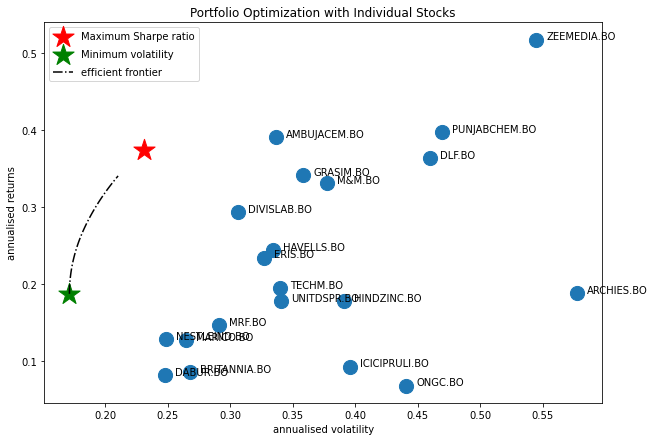

```python
display_ef_with_selected(mean_returns, cov_matrix, risk_free_rate)
```

Maximum Sharpe Ratio Portfolio Allocation

Annualised Return: 0.69 Annualised Volatility: 0.27

Symbols ITC.NS AMBUJACEM.NS ADANIPORTS.NS SBIN.NS LT.NS PATANJALI.NS \ allocation 0.0 8.25 0.0 0.0 0.0 21.15

Symbols IRB.NS FORTIS.NS LINDEINDIA.NS ESCORTS.NS ZEEL.NS CRISIL.NS \ allocation 4.05 2.13 24.88 9.1 0.0 6.23

Symbols KOTAKBANK.NS AEGISCHEM.NS HFCL.NS SUNPHARMA.NS TATACOMM.NS \ allocation 0.0 0.0 4.67 6.56 12.97

Symbols RELIANCE.NS IPL.NS CUMMINSIND.NS  
allocation 0.0 0.0 0.0

Minimum Volatility Portfolio Allocation

Annualised Return: 0.3 Annualised Volatility: 0.19

Symbols ITC.NS AMBUJACEM.NS ADANIPORTS.NS SBIN.NS LT.NS PATANJALI.NS \ allocation 15.88 6.51 0.0 0.0 0.0 3.52

Symbols IRB.NS FORTIS.NS LINDEINDIA.NS ESCORTS.NS ZEEL.NS CRISIL.NS \ allocation 0.0 11.17 1.76 0.0 0.0 13.23

Symbols KOTAKBANK.NS AEGISCHEM.NS HFCL.NS SUNPHARMA.NS TATACOMM.NS \ allocation 6.75 0.17 0.0 15.19 3.83

Symbols RELIANCE.NS IPL.NS CUMMINSIND.NS  
allocation 4.28 6.27 11.45

Individual Stock Returns and Volatility

ITC.NS : annuaised return 0.16 , annualised volatility: 0.3 AMBUJACEM.NS : annuaised return 0.39 , annualised volatility: 0.33 ADANIPORTS.NS : annuaised return 0.3 , annualised volatility: 0.4 SBIN.NS : annuaised return 0.33 , annualised volatility: 0.38 LT.NS : annuaised return 0.15 , annualised volatility: 0.31 PATANJALI.NS : annuaised return 1.3 , annualised volatility: 0.78 IRB.NS : annuaised return 0.56 , annualised volatility: 0.57 FORTIS.NS : annuaised return 0.29 , annualised volatility: 0.37 LINDEINDIA.NS : annuaised return 0.69 , annualised volatility: 0.43 ESCORTS.NS : annuaised return 0.47 , annualised volatility: 0.42 ZEEL.NS : annuaised return 0.21 , annualised volatility: 0.64 CRISIL.NS : annuaised return 0.33 , annualised volatility: 0.37 KOTAKBANK.NS : annuaised return 0.1 , annualised volatility: 0.34 AEGISCHEM.NS : annuaised return 0.31 , annualised volatility: 0.52 HFCL.NS : annuaised return 0.69 , annualised volatility: 0.62 SUNPHARMA.NS : annuaised return 0.35 , annualised volatility: 0.3 TATACOMM.NS : annuaised return 0.5 , annualised volatility: 0.44 RELIANCE.NS : annuaised return 0.25 , annualised volatility: 0.35 IPL.NS : annuaised return -0.12 , annualised volatility: 0.37 CUMMINSIND.NS : annuaised return 0.32 , annualised volatility: 0.35

[figure not shown]

Maximum Sharpe Ratio Portfolio Allocation

Annualised Return: 0.4 Annualised Volatility: 0.29

Symbols KOTAKBANK.NS TATAMOTORS.NS GRASIM.NS COALINDIA.NS SHREECEM.NS \ allocation 0.0 18.87 4.68 0.0 0.0

Symbols EICHERMOT.NS AXISBANK.NS SBIN.NS IOC.NS BPCL.NS UPL.NS \ allocation 4.12 0.0 0.0 0.0 0.0 0.0

Symbols MARUTI.NS SUNPHARMA.NS ONGC.NS BRITANNIA.NS ADANIPORTS.NS \ allocation 0.0 50.28 0.0 0.0 0.0

Symbols NESTLEIND.NS TATASTEEL.NS DRREDDY.NS  
allocation 0.0 22.05 0.0

Minimum Volatility Portfolio Allocation

Annualised Return: 0.12 Annualised Volatility: 0.18

Symbols KOTAKBANK.NS TATAMOTORS.NS GRASIM.NS COALINDIA.NS SHREECEM.NS \ allocation 6.31 0.0 0.0 6.1 1.16

Symbols EICHERMOT.NS AXISBANK.NS SBIN.NS IOC.NS BPCL.NS UPL.NS \ allocation 4.88 0.0 0.0 16.96 0.0 0.0

Symbols MARUTI.NS SUNPHARMA.NS ONGC.NS BRITANNIA.NS ADANIPORTS.NS \ allocation 0.0 8.9 0.0 11.29 0.0

Symbols NESTLEIND.NS TATASTEEL.NS DRREDDY.NS  
allocation 27.38 0.0 17.03

Individual Stock Returns and Volatility

KOTAKBANK.NS : annuaised return 0.1 , annualised volatility: 0.34 TATAMOTORS.NS : annuaised return 0.51 , annualised volatility: 0.52 GRASIM.NS : annuaised return 0.34 , annualised volatility: 0.36 COALINDIA.NS : annuaised return 0.12 , annualised volatility: 0.37 SHREECEM.NS : annuaised return 0.08 , annualised volatility: 0.32 EICHERMOT.NS : annuaised return 0.27 , annualised volatility: 0.34 AXISBANK.NS : annuaised return 0.18 , annualised volatility: 0.44 SBIN.NS : annuaised return 0.33 , annualised volatility: 0.38 IOC.NS : annuaised return -0.08 , annualised volatility: 0.3 BPCL.NS : annuaised return -0.12 , annualised volatility: 0.38 UPL.NS : annuaised return 0.14 , annualised volatility: 0.41 MARUTI.NS : annuaised return 0.14 , annualised volatility: 0.35 SUNPHARMA.NS : annuaised return 0.35 , annualised volatility: 0.3 ONGC.NS : annuaised return 0.07 , annualised volatility: 0.44 BRITANNIA.NS : annuaised return 0.08 , annualised volatility: 0.27 ADANIPORTS.NS : annuaised return 0.3 , annualised volatility: 0.4 NESTLEIND.NS : annuaised return 0.13 , annualised volatility: 0.25 TATASTEEL.NS : annuaised return 0.46 , annualised volatility: 0.44 DRREDDY.NS : annuaised return 0.2 , annualised volatility: 0.29

[figure not shown]

Maximum Sharpe Ratio Portfolio Allocation

Annualised Return: 1.12 Annualised Volatility: 0.2

Symbols BOMOXY-B1.BO AXISBANK.BO IKAB.BO JPOLYINVST.BO ICRA.BO \ allocation 0.0 0.0 28.13 13.02 2.75

Symbols KOTAKBANK.BO DHUNINV.BO SBILIFE.BO PILANIINVS.BO ICICIBANK.BO \ allocation 0.0 1.57 0.0 0.0 0.0

Symbols THACKER.BO ORACLECR.BO JINDALPHOT.BO CGCL.BO CANBK.BO \ allocation 5.67 15.07 5.81 6.37 0.0

Symbols MONARCH.BO SUMEDHA.BO SYSTMTXC.BO INDOTHAI.BO SILINV.BO  
allocation 4.86 5.0 7.41 4.34 0.0

Minimum Volatility Portfolio Allocation

Annualised Return: 0.59 Annualised Volatility: 0.15

Symbols BOMOXY-B1.BO AXISBANK.BO IKAB.BO JPOLYINVST.BO ICRA.BO \ allocation 6.53 0.0 11.88 4.6 16.35

Symbols KOTAKBANK.BO DHUNINV.BO SBILIFE.BO PILANIINVS.BO ICICIBANK.BO \ allocation 6.38 1.48 12.48 2.99 0.0

Symbols THACKER.BO ORACLECR.BO JINDALPHOT.BO CGCL.BO CANBK.BO \ allocation 9.66 7.32 0.99 8.16 0.0

Symbols MONARCH.BO SUMEDHA.BO SYSTMTXC.BO INDOTHAI.BO SILINV.BO  
allocation 0.0 1.94 7.39 1.86 0.0

Individual Stock Returns and Volatility

BOMOXY-B1.BO : annuaised return 0.05 , annualised volatility: 0.48 AXISBANK.BO : annuaised return 0.18 , annualised volatility: 0.44 IKAB.BO : annuaised return 1.46 , annualised volatility: 0.42 JPOLYINVST.BO : annuaised return 1.47 , annualised volatility: 0.55 ICRA.BO : annuaised return 0.23 , annualised volatility: 0.34 KOTAKBANK.BO : annuaised return 0.1 , annualised volatility: 0.34 DHUNINV.BO : annuaised return 0.58 , annualised volatility: 0.61 SBILIFE.BO : annuaised return 0.13 , annualised volatility: 0.31 PILANIINVS.BO : annuaised return 0.08 , annualised volatility: 0.42 ICICIBANK.BO : annuaised return 0.31 , annualised volatility: 0.38 THACKER.BO : annuaised return 0.55 , annualised volatility: 0.46 ORACLECR.BO : annuaised return 1.11 , annualised volatility: 0.48 JINDALPHOT.BO : annuaised return 1.35 , annualised volatility: 0.67 CGCL.BO : annuaised return 0.53 , annualised volatility: 0.44 CANBK.BO : annuaised return 0.26 , annualised volatility: 0.49 MONARCH.BO : annuaised return 1.12 , annualised volatility: 0.63 SUMEDHA.BO : annuaised return 0.99 , annualised volatility: 0.7 SYSTMTXC.BO : annuaised return 0.67 , annualised volatility: 0.49 INDOTHAI.BO : annuaised return 0.89 , annualised volatility: 0.64 SILINV.BO : annuaised return 0.4 , annualised volatility: 0.52

[figure not shown]

Maximum Sharpe Ratio Portfolio Allocation

Annualised Return: 0.55 Annualised Volatility: 0.29

Symbols SUNPHARMA.BO DRREDDY.BO DIVISLAB.BO CIPLA.BO BIOCON.BO \ allocation 3.46 0.0 0.0 23.19 0.0

Symbols TORNTPHARM.BO AUROPHARMA.BO LUPIN.BO ABBOTINDIA.BO ALKEM.BO \ allocation 0.0 0.0 0.0 1.36 0.0

Symbols APOLLOHOSP.BO IPCALAB.BO GLAXO.BO PFIZER.BO SYNGENE.BO \ allocation 18.19 1.78 0.0 0.0 0.0

Symbols APLLTD.BO SANOFI.BO LALPATHLAB.BO LAURUSLABS.BO NATCOPHARM.BO  
allocation 0.0 0.0 3.16 48.87 0.0

Minimum Volatility Portfolio Allocation

Annualised Return: 0.13 Annualised Volatility: 0.16

Symbols SUNPHARMA.BO DRREDDY.BO DIVISLAB.BO CIPLA.BO BIOCON.BO \ allocation 1.11 6.36 0.0 2.68 0.0

Symbols TORNTPHARM.BO AUROPHARMA.BO LUPIN.BO ABBOTINDIA.BO ALKEM.BO \ allocation 0.31 0.0 0.0 7.5 12.13

Symbols APOLLOHOSP.BO IPCALAB.BO GLAXO.BO PFIZER.BO SYNGENE.BO \ allocation 0.0 0.65 15.26 11.9 9.1

Symbols APLLTD.BO SANOFI.BO LALPATHLAB.BO LAURUSLABS.BO NATCOPHARM.BO  
allocation 0.66 22.77 5.53 0.0 4.04

Individual Stock Returns and Volatility

SUNPHARMA.BO : annuaised return 0.35 , annualised volatility: 0.3 DRREDDY.BO : annuaised return 0.2 , annualised volatility: 0.29 DIVISLAB.BO : annuaised return 0.29 , annualised volatility: 0.31 CIPLA.BO : annuaised return 0.36 , annualised volatility: 0.3 BIOCON.BO : annuaised return 0.08 , annualised volatility: 0.34 TORNTPHARM.BO : annuaised return 0.1 , annualised volatility: 0.43 AUROPHARMA.BO : annuaised return 0.13 , annualised volatility: 0.44 LUPIN.BO : annuaised return 0.04 , annualised volatility: 0.34 ABBOTINDIA.BO : annuaised return 0.23 , annualised volatility: 0.29 ALKEM.BO : annuaised return 0.19 , annualised volatility: 0.28 APOLLOHOSP.BO : annuaised return 0.44 , annualised volatility: 0.4 IPCALAB.BO : annuaised return 0.29 , annualised volatility: 0.79 GLAXO.BO : annuaised return 0.01 , annualised volatility: 0.27 PFIZER.BO : annuaised return 0.13 , annualised volatility: 0.27 SYNGENE.BO : annuaised return 0.25 , annualised volatility: 0.33 APLLTD.BO : annuaised return 0.07 , annualised volatility: 0.35 SANOFI.BO : annuaised return -0.0 , annualised volatility: 0.23 LALPATHLAB.BO : annuaised return 0.27 , annualised volatility: 0.4 LAURUSLABS.BO : annuaised return 0.73 , annualised volatility: 0.43 NATCOPHARM.BO : annuaised return 0.07 , annualised volatility: 0.34

[figure not shown]